# Dissertation 2026-Data Analysis

2026-06-16

```r
# Install all required packages (run once)
install.packages("tidyverse")      # data manipulation and ggplot2 for visualisations
install.packages("janitor")        # clean_names()
install.packages("psych")          # EFA, Cronbach's alpha
install.packages("car")            # VIF
install.packages("lmtest")         # Breusch-Pagan
install.packages("boot")           # bootstrapping
install.packages("gt")             # tables
install.packages("gtsummary")      # descriptives table
install.packages("effectsize")     # eta squared
install.packages("moments")        # skewness and kurtosis
install.packages("ggplot2")        # visualisations (included in tidyverse)
```

### Loading required packages

```r
library(tidyverse)
library(janitor)
library(psych)
library(car)
library(lmtest)
library(boot)
library(gt)
library(gtsummary)
library(effectsize)
library(moments)
library (ez)
```

### Load file

```r
df <- read_csv("Dissertation/210.csv")
dim(df)
```

```
## [1] 210  79
```

### standardise column names and creating condition variables

```r
df <- clean_names(df)

df <- df %>%
  mutate(condition = case_when(
    !is.na(mpq7) ~ "MP",
    !is.na(emq7) ~ "EM",
    !is.na(arq7) ~ "AR",
    TRUE ~ NA_character_
  ))

table(df$condition)
```

```
##
## AR EM MP
## 70 69 71
```

### Coalescing to create a single shared column to compare across conditions

```r
df <- df %>%
  mutate(
    ai_use_1 = coalesce(mpq2_1, emq2_1, arq2_1),
    ai_use_2 = coalesce(mpq2_2, emq2_2, arq2_2),
    ai_use_3 = coalesce(mpq2_3, emq2_3, arq2_3),
    ai_use_4 = coalesce(mpq2_4, emq2_4, arq2_4),
    ai_use_5 = coalesce(mpq2_5, emq2_5, arq2_5),
    ai_use_6 = coalesce(mpq2_6, emq2_6, arq2_6),
    ai_disclosure_1 = coalesce(mpq3_1, emq3_1, arq3_1),
    ai_disclosure_2 = coalesce(mpq3_2, emq3_2, arq3_2),
    ai_disclosure_3 = coalesce(mpq3_3, emq3_3, arq3_3),
    ai_disclosure_4 = coalesce(mpq3_4, emq3_4, arq3_4),
    ai_disclosure_5 = coalesce(mpq3_5, emq3_5, arq3_5),
    ai_disclosure_6 = coalesce(mpq3_6, emq3_6, arq3_6),
    mancheck1_1 = coalesce(mpq4_1, emq4_1, arq4_1),
    mancheck1_2 = coalesce(mpq4_2, emq4_2, arq4_2),
    mancheck1_3 = coalesce(mpq4_3, emq4_3, arq4_3),
    mancheck2_1 = coalesce(mpq5_1, emq5_1, arq5_1),
    mancheck2_2 = coalesce(mpq5_2, emq5_2, arq5_2),
    mancheck2_3 = coalesce(mpq5_3, emq5_3, arq5_3)
  )
```

### Recoding AI diclosure (scale of 1-6 to 1-5) by collapting 1 and 2 (I do not use AI and Most Unlikely)

```r
recode_disclosure <- function(x) {
  case_when(
    x == 1 ~ 1,
    x == 2 ~ 1,
    x == 3 ~ 2,
    x == 4 ~ 3,
    x == 5 ~ 4,
    x == 6 ~ 5,
    TRUE ~ NA_real_
  )
}

df <- df %>%
  mutate(across(starts_with("ai_disclosure"), recode_disclosure))

# NA check - should all be 0
df %>%
  select(starts_with("ai_use"), starts_with("ai_disclosure"),
         starts_with("mancheck")) %>%
  summarise(across(everything(), ~sum(is.na(.))))
```

```
## # A tibble: 1 × 18
##   ai_use_1 ai_use_2 ai_use_3 ai_use_4 ai_use_5 ai_use_6 ai_disclosure_1
##      <int>    <int>    <int>    <int>    <int>    <int>           <int>
## 1        0        0        0        0        0        0               0
## # ℹ 11 more variables: ai_disclosure_2 <int>, ai_disclosure_3 <int>,
## #   ai_disclosure_4 <int>, ai_disclosure_5 <int>, ai_disclosure_6 <int>,
## #   mancheck1_1 <int>, mancheck1_2 <int>, mancheck1_3 <int>, mancheck2_1 <int>,
## #   mancheck2_2 <int>, mancheck2_3 <int>
```

### Checking Missing Data (across all columns)

```r
missing_summary <- df %>%
  summarise(across(everything(), ~sum(is.na(.)))) %>%
  pivot_longer(everything(), names_to = "variable", values_to = "n_missing") %>%
  filter(n_missing > 0) %>%
  mutate(percent_missing = round(n_missing / nrow(df) * 100, 1)) %>%
  arrange(desc(n_missing))

print(missing_summary)
```

```
## # A tibble: 69 × 3
##    variable    n_missing percent_missing
##    <chr>           <int>           <dbl>
##  1 b2q9_6_text       209            99.5
##  2 b2q2_6_text       183            87.1
##  3 b2q10             162            77.1
##  4 emq1_4            141            67.1
##  5 emq1_5            141            67.1
##  6 emq2_1            141            67.1
##  7 emq2_2            141            67.1
##  8 emq2_3            141            67.1
##  9 emq2_4            141            67.1
## 10 emq2_5            141            67.1
## # ℹ 59 more rows
```

### Comprehension Check

```r
df <- df %>%
  mutate(
    comprehension_fail = case_when(
      condition == "MP" & mpq7 != 2 ~ TRUE,
      condition == "EM" & emq7 != 2 ~ TRUE,
      condition == "AR" & arq7 != 2 ~ TRUE,
      TRUE ~ FALSE
    )
  )

# how many failed by condition
df %>%
  group_by(condition) %>%
  summarise(n_failed = sum(comprehension_fail))
```

```
## # A tibble: 3 × 2
##   condition n_failed
##   <chr>        <int>
## 1 AR               3
## 2 EM               2
## 3 MP               4
```

```r
#primary sample excluding comprehension failures
df_primary <- df %>%
  filter(comprehension_fail == FALSE)

#sample size and condition counts
cat("Primary sample size:", nrow(df_primary), "\n")
```

```
## Primary sample size: 201
```

```r
table(df_primary$condition)
```

```
##
## AR EM MP
## 67 67 67
```

### Comprehension check and exclusion - n = 201, 9 fails (excluded)

## Who failed comprehension check?

```r
#comprehension failures are disproportionately non-native English speakers?
df %>%
  mutate(native_english = ifelse(b2q4 == 1, "Native", "Non-native")) %>%
  group_by(comprehension_fail, native_english) %>%
  summarise(n = n()) %>%
  pivot_wider(names_from = native_english, values_from = n, values_fill = 0) %>%
  mutate(total = Native + `Non-native`,
         pct_non_native = round(`Non-native` / total * 100, 1))
```

```
## `summarise()` has regrouped the output.
## ℹ Summaries were computed grouped by comprehension_fail and native_english.
## ℹ Output is grouped by comprehension_fail.
## ℹ Use `summarise(.groups = "drop_last")` to silence this message.
## ℹ Use `summarise(.by = c(comprehension_fail, native_english))` for
##   per-operation grouping (`?dplyr::dplyr_by`) instead.
```

```
## # A tibble: 2 × 5
## # Groups:   comprehension_fail [2]
##   comprehension_fail Native `Non-native` total pct_non_native
##   <lgl>               <int>        <int> <int>          <dbl>
## 1 FALSE                 165           36   201           17.9
## 2 TRUE                    1            8     9           88.9
```

# RESULT: 8 out of 9 are non native English speakers

### Inconsistency check

```r
# Flag items where ai_use = 1 (Highly Unlikely) but ai_disclosure >= 3
df_primary <- df_primary %>%
  mutate(
    inconsistent_1 = ai_use_1 == 1 & ai_disclosure_1 >= 3,
    inconsistent_2 = ai_use_2 == 1 & ai_disclosure_2 >= 3,
    inconsistent_3 = ai_use_3 == 1 & ai_disclosure_3 >= 3,
    inconsistent_4 = ai_use_4 == 1 & ai_disclosure_4 >= 3,
    inconsistent_5 = ai_use_5 == 1 & ai_disclosure_5 >= 3,
    inconsistent_6 = ai_use_6 == 1 & ai_disclosure_6 >= 3,
    n_inconsistent = inconsistent_1 + inconsistent_2 + inconsistent_3 +
                     inconsistent_4 + inconsistent_5 + inconsistent_6
  )

# Distribution of inconsistent items
table(df_primary$n_inconsistent)
```

```
##
##   0   1   2   3   4   5
## 174  11   8   4   2   2
```

```r
# How many participants have at least one inconsistency
sum(df_primary$n_inconsistent > 0)
```

```
## [1] 27
```

### recoding categorical variables

```r
# Recode categorical variables (demographics)
df_primary <- df_primary %>%
  mutate(
    level_of_study = case_when(
      b2q1 == 1 ~ "Undergraduate",
      b2q1 == 2 ~ "Postgraduate Taught",
      b2q1 == 3 ~ "Postgraduate Research",
      TRUE ~ NA_character_
    ),
    field_of_study = case_when(
      b2q2 == 1 ~ "Humanities and Arts",
      b2q2 == 2 ~ "Social Sciences",
      b2q2 == 3 ~ "Politics, Law and International Relations",
      b2q2 == 4 ~ "Economics and Business",
      b2q2 == 5 ~ "STEM",
      b2q2 == 6 ~ "Other",
      TRUE ~ NA_character_
    ),
    gender = case_when(
      b2q3 == 1 ~ "Female",
      b2q3 == 2 ~ "Male",
      b2q3 == 3 ~ "Non-Binary",
      b2q3 == 4 ~ "Prefer not to say",
      b2q3 == 5 ~ "Other",
      TRUE ~ NA_character_
    ),
    english_proficiency_label = case_when(
      b2q4 == 1 ~ "Native speaker",
      b2q4 == 2 ~ "Fluent non-native speaker",
      b2q4 == 3 ~ "Intermediate",
      b2q4 == 4 ~ "Basic",
      TRUE ~ NA_character_
    ),
    ai_frequency = case_when(
      b2q8 == 1 ~ "Never",
      b2q8 == 2 ~ "Rarely",
      b2q8 == 3 ~ "Sometimes",
      b2q8 == 4 ~ "Often",
      b2q8 == 5 ~ "Very often",
      TRUE ~ NA_character_
    ),
    recruitment = case_when(
      b2q9 == 1 ~ "Prolific",
      b2q9 == 2 ~ "Social media",
      b2q9 == 3 ~ "WhatsApp or messaging app",
      b2q9 == 4 ~ "Reddit",
      b2q9 == 5 ~ "Personal Networks",
      b2q9 == 6 ~ "Other",
      TRUE ~ NA_character_
    )
  )
```

### Breakdown of participants from convenience sampling and prolific

```r
# Add sample identifier using original response_id order
prolific_ids <- df %>%
  slice(1:(nrow(df) - 33)) %>%
  pull(response_id)

df_primary <- df_primary %>%
  mutate(sample = ifelse(response_id %in% prolific_ids, "prolific", "convenience"))

table(df_primary$sample, df_primary$condition)
```

```
##
##               AR EM MP
##   convenience  7  7 10
##   prolific    60 60 57
```

# Descriptives Table

```r
df_primary %>%
  tbl_summary(
    include = c(level_of_study, field_of_study, gender,
                english_proficiency_label, ai_frequency, recruitment),
    statistic = list(all_categorical() ~ "{n} ({p}%)"),
    label = list(
      level_of_study            ~ "Level of Study",
      field_of_study            ~ "Field of Study",
      gender                    ~ "Gender",
      english_proficiency_label ~ "English Proficiency",
      ai_frequency              ~ "AI Use Frequency",
      recruitment               ~ "Recruitment Source"
    )
  ) %>%
  modify_caption("Table 1. Sample Descriptive Statistics (N = 201)")
```

Table 1. Sample Descriptive Statistics (N = 201)

| **Characteristic** | **N = 201**<sup>1</sup> |
| --- | --- |
| Level of Study |  |
| Postgraduate Research | 15 (7.5%) |
| Postgraduate Taught | 63 (31%) |
| Undergraduate | 123 (61%) |
| Field of Study |  |
| Economics and Business | 24 (12%) |
| Humanities and Arts | 15 (7.5%) |
| Other | 26 (13%) |
| Politics, Law and International Relations | 13 (6.5%) |
| Social Sciences | 52 (26%) |
| STEM | 71 (35%) |
| Gender |  |
| Female | 106 (53%) |
| Male | 91 (45%) |
| Non-Binary | 1 (0.5%) |
| Prefer not to say | 3 (1.5%) |
| English Proficiency |  |
| Fluent non-native speaker | 32 (16%) |
| Intermediate | 4 (2.0%) |
| Native speaker | 165 (82%) |
| AI Use Frequency |  |
| Never | 12 (6.0%) |
| Often | 65 (32%) |
| Rarely | 48 (24%) |
| Sometimes | 50 (25%) |
| Very often | 26 (13%) |
| Recruitment Source |  |
| Other | 1 (0.5%) |
| Personal Networks | 9 (4.5%) |
| Prolific | 177 (88%) |
| WhatsApp or messaging app | 14 (7.0%) |

<sup>1</sup> n (%)

### Audit - Country of Adolescence and Citizenship

```r
# Check country of adolescence (b2q6) and country of citizenship (b2q7)
df_primary %>% count(b2q6) %>% arrange(desc(n)) %>% print(n = 50)
```

```
## # A tibble: 51 × 2
##    b2q6                             n
##    <chr>                        <int>
##  1 United Kingdom                  54
##  2 England                         41
##  3 UK                              22
##  4 england                          7
##  5 Kenya                            4
##  6 Nigeria                          4
##  7 Scotland                         4
##  8 Wales                            4
##  9 Germany                          3
## 10 India                            3
## 11 Ireland                          3
## 12 Italy                            3
```

[output cut: 39 more lines]

```r
df_primary %>% count(b2q7) %>% arrange(desc(n)) %>% print(n = 50)
```

```
## # A tibble: 68 × 2
##    b2q7                                  n
##    <chr>                             <int>
##  1 United Kingdom                       58
##  2 UK                                   29
##  3 England                              23
##  4 england                               5
##  5 USA                                   4
##  6 Ireland                               3
##  7 Kenya                                 3
##  8 Nigeria                               3
##  9 British                               2
## 10 Ecuador                               2
## 11 Germany                               2
## 12 India                                 2
```

[output cut: 39 more lines]

### Country standardisation + Overlap

```r
# b2q6 = country of adolescence (used for UAI mapping)
# b2q7 = country of citizenship (descriptive only)

# Standardise country of adolescence (b2q6)
df_primary <- df_primary %>%
  mutate(country_adolescence = case_when(
    grepl("england|uk|united kingdom|scotland|wales|britain|britian",
          tolower(b2q6)) ~ "United Kingdom",
    tolower(b2q6) == "austria"                        ~ "Austria",
    tolower(b2q6) == "bahrain"                        ~ "Bahrain",
    tolower(b2q6) == "bangladesh"                     ~ "Bangladesh",
    tolower(b2q6) == "canada"                         ~ "Canada",
    tolower(b2q6) == "china"                          ~ "China",
    tolower(b2q6) == "colombia"                       ~ "Colombia",
    tolower(b2q6) == "ecuador"                        ~ "Ecuador",
    tolower(b2q6) == "germany"                        ~ "Germany",
    tolower(b2q6) == "ghana"                          ~ "Ghana",
    tolower(b2q6) == "india"                          ~ "India",
    tolower(b2q6) == "indonesia"                      ~ "Indonesia",
    tolower(b2q6) == "ireland"                        ~ "Ireland",
    tolower(b2q6) == "italy"                          ~ "Italy",
    tolower(b2q6) == "jamaica"                        ~ "Jamaica",
    grepl("kenya", tolower(b2q6))                     ~ "Kenya",
    tolower(b2q6) == "latvia"                         ~ "Latvia",
    tolower(b2q6) == "malaysia"                       ~ "Malaysia",
    tolower(b2q6) == "nepal"                          ~ "Nepal",
    tolower(b2q6) == "nigeria"                        ~ "Nigeria",
    tolower(b2q6) == "north macedonia"                ~ "North Macedonia",
    tolower(b2q6) == "pakistan"                       ~ "Pakistan",
    tolower(b2q6) == "peru"                           ~ "Peru",
    tolower(b2q6) == "romania"                        ~ "Romania",
    tolower(b2q6) == "saudi arabia"                   ~ "Saudi Arabia",
    tolower(b2q6) == "serbia"                         ~ "Serbia",
    tolower(b2q6) == "south africa"                   ~ "South Africa",
    tolower(b2q6) == "south korea"                    ~ "South Korea",
    tolower(b2q6) == "spain"                          ~ "Spain",
    grepl("united arab emirates|uae", tolower(b2q6)) ~ "United Arab Emirates",
    tolower(b2q6) == "united states" | tolower(b2q6) == "usa" ~ "United States",
    tolower(b2q6) == "zimbabwe"                       ~ "Zimbabwe",
    tolower(b2q6) == "argentina"                      ~ "Argentina",
    tolower(b2q6) == "armenia"                        ~ "Armenia",
    tolower(b2q6) == "brazil"                         ~ "Brazil",
    tolower(b2q6) == "paraguay"                       ~ "Paraguay",
    tolower(b2q6) == "qatar"                          ~ "Qatar",
    TRUE ~ NA_character_
  ))

# Standardise country of citizenship (b2q7)
df_primary <- df_primary %>%
  mutate(country_citizenship = case_when(
    grepl("england|uk|united kingdom|scotland|wales|britain|britian|british",
          tolower(b2q7)) ~ "United Kingdom",
    grepl("kenya|kenyan", tolower(b2q7))              ~ "Kenya",
    grepl("nigeria|nigerian", tolower(b2q7))          ~ "Nigeria",
    grepl("india|indian", tolower(b2q7))              ~ "India",
    tolower(b2q7) == "austria"                        ~ "Austria",
    tolower(b2q7) == "bangladesh"                     ~ "Bangladesh",
    tolower(b2q7) == "canada"                         ~ "Canada",
    grepl("china|chian", tolower(b2q7))               ~ "China",
    tolower(b2q7) == "colombia"                       ~ "Colombia",
    tolower(b2q7) == "ecuador"                        ~ "Ecuador",
    grepl("german", tolower(b2q7))                    ~ "Germany",
    grepl("ireland|irelnd", tolower(b2q7))            ~ "Ireland",
    grepl("italy|ita", tolower(b2q7))                 ~ "Italy",
    tolower(b2q7) == "jamaica"                        ~ "Jamaica",
    tolower(b2q7) == "latvia"                         ~ "Latvia",
    tolower(b2q7) == "malaysia"                       ~ "Malaysia",
    tolower(b2q7) == "nepal"                          ~ "Nepal",
    tolower(b2q7) == "pakistan"                       ~ "Pakistan",
    tolower(b2q7) == "peru"                           ~ "Peru",
    tolower(b2q7) == "poland"                         ~ "Poland",
    tolower(b2q7) == "portugal"                       ~ "Portugal",
    tolower(b2q7) == "romania"                        ~ "Romania",
    tolower(b2q7) == "serbia"                         ~ "Serbia",
    tolower(b2q7) == "south africa"                   ~ "South Africa",
    tolower(b2q7) == "south korea"                    ~ "South Korea",
    tolower(b2q7) == "spain"                          ~ "Spain",
    tolower(b2q7) == "united states" | tolower(b2q7) == "usa" ~ "United States",
    tolower(b2q7) == "zimbabwe"                       ~ "Zimbabwe",
    tolower(b2q7) == "-" | tolower(b2q7) == "prefer not to mention" ~ NA_character_,
    TRUE ~ NA_character_
  ))

# Check NAs
cat("NAs in country_adolescence:", sum(is.na(df_primary$country_adolescence)), "\n")
```

```
## NAs in country_adolescence: 2
```

```r
cat("NAs in country_citizenship:", sum(is.na(df_primary$country_citizenship)), "\n")
```

```
## NAs in country_citizenship: 4
```

```r
# Overlap check
overlap <- df_primary %>%
  mutate(same_country = country_adolescence == country_citizenship) %>%
  summarise(
    same = sum(same_country, na.rm = TRUE),
    different = sum(!same_country, na.rm = TRUE),
    total = n()
  )
print(overlap)
```

```
## # A tibble: 1 × 3
##    same different total
##   <int>     <int> <int>
## 1   181        16   201
```

### UAI mapping - country of adolescence

```r
uai_scores <- c(
  "Argentina"            = 86,
  "Armenia"              = 73,
  "Austria"              = 70,
  "Bahrain"              = 68,
  "Bangladesh"           = 60,
  "Brazil"               = 76,
  "Canada"               = 48,
  "China"                = 30,
  "Colombia"             = 80,
  "Ecuador"              = 67,
  "Germany"              = 65,
  "Ghana"                = 54,
  "India"                = 40,
  "Indonesia"            = 48,
  "Ireland"              = 35,
  "Italy"                = 75,
  "Jamaica"              = 13,
  "Kenya"                = 50,
  "Latvia"               = 63,
  "Malaysia"             = 36,
  "Nepal"                = 40,
  "Nigeria"              = 55,
  "North Macedonia"      = 85,
  "Pakistan"             = 70,
  "Paraguay"             = 86,
  "Peru"                 = 87,
  "Qatar"                = 80,
  "Romania"              = 90,
  "Saudi Arabia"         = 80,
  "Serbia"               = 92,
  "South Africa"         = 49,
  "South Korea"          = 85,
  "Spain"                = 86,
  "United Arab Emirates" = 80,
  "United Kingdom"       = 35,
  "United States"        = 46,
  "Zimbabwe"             = 50
)

df_primary <- df_primary %>%
  mutate(uai = uai_scores[country_adolescence])

# Verify
cat("NAs in UAI:", sum(is.na(df_primary$uai)), "\n")
```

```
## NAs in UAI: 2
```

```r
summary(df_primary$uai)
```

```
##    Min. 1st Qu.  Median    Mean 3rd Qu.    Max.    NA's
##   13.00   35.00   35.00   41.44   35.00   92.00       2
```

## 2 NAs, UAI range 13–92

### Country of Adolescence descriptives table

```r
uai_table <- df_primary %>%
  count(country_adolescence) %>%
  filter(!is.na(country_adolescence)) %>%
  mutate(uai = uai_scores[country_adolescence]) %>%
  arrange(desc(n)) %>%
  rename(Country = country_adolescence, N = n, UAI = uai)

uai_table %>%
  gt() %>%
  tab_header(title = "Table 3. Country of Adolescence and Hofstede UAI Scores (N = 199)") %>%
  cols_label(
    Country = "Country",
    N       = "N",
    UAI     = "UAI Score"
  ) %>%
  tab_footnote(
    footnote = "UAI scores sourced from Hofstede Insights (2023). Higher scores indicate greater uncertainty avoidance.",
    locations = cells_column_labels(columns = UAI)
  )
```

Table 3. Country of Adolescence and Hofstede UAI Scores (N = 199)

| Country | N | UAI Score<sup>1</sup> |
| --- | --- | --- |
| United Kingdom | 146 | 35 |
| Kenya | 5 | 50 |
| Nigeria | 4 | 55 |
| United States | 4 | 46 |
| Germany | 3 | 65 |
| India | 3 | 40 |
| Ireland | 3 | 35 |
| Italy | 3 | 75 |
| Ecuador | 2 | 67 |
| Latvia | 2 | 63 |
| Peru | 2 | 87 |
| Romania | 2 | 90 |
| Austria | 1 | 70 |
| Bahrain | 1 | 68 |
| Bangladesh | 1 | 60 |
| Canada | 1 | 48 |
| China | 1 | 30 |
| Colombia | 1 | 80 |
| Ghana | 1 | 54 |
| Indonesia | 1 | 48 |
| Jamaica | 1 | 13 |
| Malaysia | 1 | 36 |
| Nepal | 1 | 40 |
| North Macedonia | 1 | 85 |
| Pakistan | 1 | 70 |
| Saudi Arabia | 1 | 80 |
| Serbia | 1 | 92 |
| South Africa | 1 | 49 |
| South Korea | 1 | 85 |
| Spain | 1 | 86 |
| United Arab Emirates | 1 | 80 |
| Zimbabwe | 1 | 50 |

<sup>1</sup> UAI scores sourced from Hofstede Insights (2023). Higher scores indicate greater uncertainty avoidance.

### As the scale items were adapted for this study, EFA is used to understand associations between all the factors. Parallel analysis is used to determine the number of factors for each scales. It compares eigenvalues from real data against random data of the same size and retains factors that explain more variance than chance.

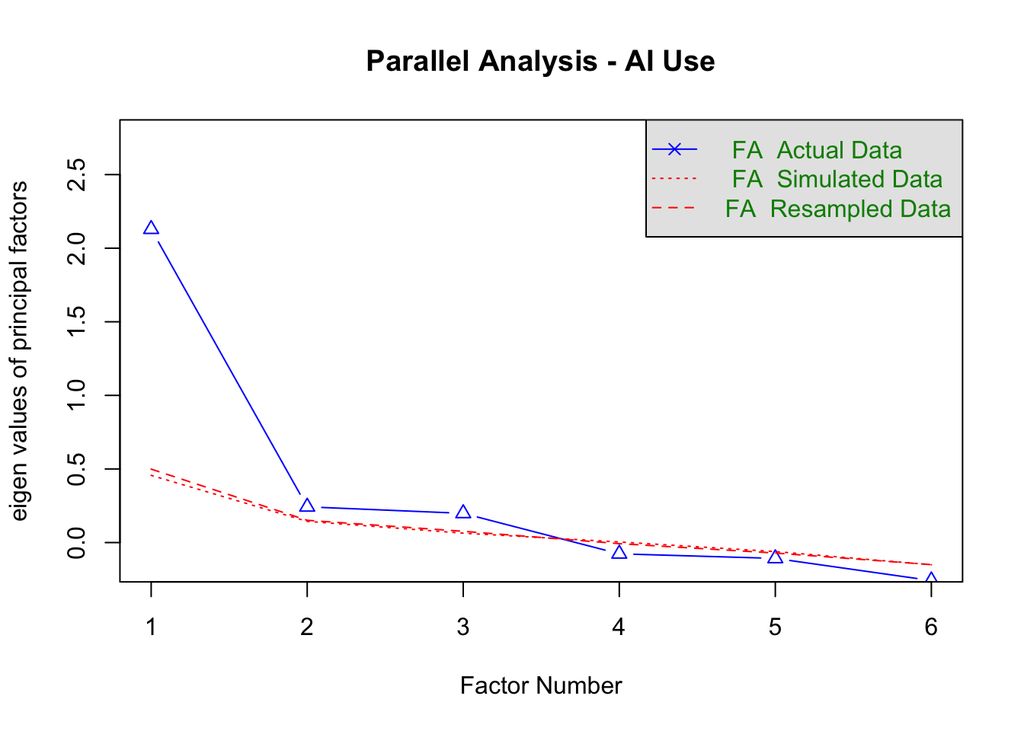

```
## Parallel analysis suggests that the number of factors =  3  and the number of components =  NA
```

```r
# Select items
ai_use_items <- df_primary %>% select(starts_with("ai_use"))
ai_disclosure_items <- df_primary %>% select(starts_with("ai_disclosure"))

# Parallel analysis
fa.parallel(ai_use_items, fm = "pa", fa = "fa",
            main = "Parallel Analysis - AI Use")
```

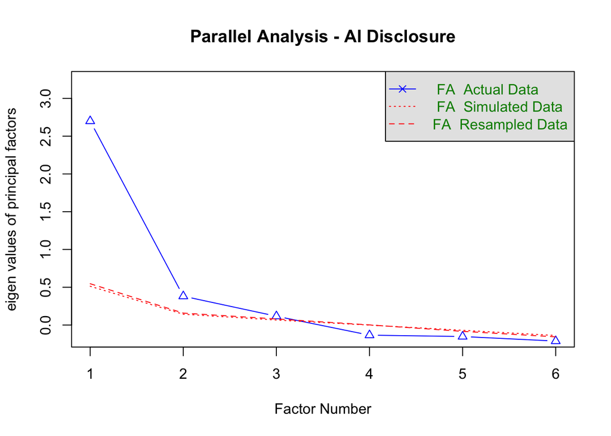

```
## Parallel analysis suggests that the number of factors =  3  and the number of components =  NA
```

```r
fa.parallel(ai_disclosure_items, fm = "pa", fa = "fa",
            main = "Parallel Analysis - AI Disclosure")
```

### Which items cluster together onto which factors, which then tells you whether your scale items are measuring one thing or multiple distinct dimensions.

```r
# Principal axis factoring (fm = "pa") with oblimin rotation (oblique) allows factors to correlate, appropriate for psychological constructs. The cutoff = 0.3.

# AI Use - 3 factor solution (parallel analysis suggestion)
efa_ai_use_3 <- fa(ai_use_items, nfactors = 3, fm = "pa", rotate = "oblimin")
```

```
## maximum iteration exceeded
```

```r
print(efa_ai_use_3$loadings, cutoff = 0.3)
```

```
##
## Loadings:
##          PA1    PA2    PA3
## ai_use_1  0.621
## ai_use_2  0.604
## ai_use_3                0.896
## ai_use_4  0.423         0.427
## ai_use_5         0.930
## ai_use_6  0.346  0.353
##
##                  PA1   PA2   PA3
## SS loadings    1.049 1.023 1.015
## Proportion Var 0.175 0.170 0.169
## Cumulative Var 0.175 0.345 0.514
```

## RESULTS: Nearly equal variance across factors (17.5%, 17.0%, 16.9%) — no meaningful structure, Items 4 and 6 cross-load, Overall– 3-factor solution is not interpretable

```r
# AI Use - 2 factor solution
efa_ai_use_2 <- fa(ai_use_items, nfactors = 2, fm = "pa", rotate = "oblimin")
```

```
## maximum iteration exceeded
```

```r
print(efa_ai_use_2$loadings, cutoff = 0.3)
```

```
##
## Loadings:
##          PA1    PA2
## ai_use_1  0.546
## ai_use_2  0.715
## ai_use_3         1.128
## ai_use_4  0.451
## ai_use_5  0.488
## ai_use_6  0.549
##
##                  PA1   PA2
## SS loadings    1.552 1.400
## Proportion Var 0.259 0.233
## Cumulative Var 0.259 0.492
```

## Results: Heywood case confirmed — ai_use_3 loading at 1.128, unstable solution.

```r
# AI Use - 1 factor solution
efa_ai_use_1 <- fa(ai_use_items, nfactors = 1, fm = "pa", rotate = "none")
print(efa_ai_use_1$loadings, cutoff = 0.3)
```

```
##
## Loadings:
##          PA1
## ai_use_1 0.515
## ai_use_2 0.600
## ai_use_3 0.657
## ai_use_4 0.657
## ai_use_5 0.658
## ai_use_6 0.455
##
##                  PA1
## SS loadings    2.129
## Proportion Var 0.355
```

## RESULT: Stable — all loadings 0.46–0.66, 35.5% variance explained, no warnings. 1-factor solution confirmed for ai_use

```r
# AI Disclosure - 2 factor solution (based on prior stable solution)
efa_ai_disclosure_2 <- fa(ai_disclosure_items, nfactors = 2, fm = "pa", rotate = "oblimin")
print(efa_ai_disclosure_2$loadings, cutoff = 0.3)
```

```
##
## Loadings:
##                 PA1    PA2
## ai_disclosure_1         0.742
## ai_disclosure_2         0.584
## ai_disclosure_3  0.536  0.333
## ai_disclosure_4         0.588
## ai_disclosure_5  0.934
## ai_disclosure_6  0.683
##
##                  PA1   PA2
## SS loadings    1.695 1.356
## Proportion Var 0.283 0.226
## Cumulative Var 0.283 0.509
```

## Factor loading tables

```r
# Extract loadings for 1-factor ai_use
loadings_use <- as.data.frame(unclass(efa_ai_use_1$loadings)) %>%
  round(3) %>%
  rownames_to_column("Item") %>%
  mutate(
    Item = c("Brainstorming ideas and refining topic",
             "Conducting literature review",
             "Rewriting paragraphs or sentences",
             "Evaluating or assessing writing",
             "Writing parts of essay",
             "Summarising without reading source"),
    Scale = "AI Use"
  )
names(loadings_use)[2] <- "Factor 1"

# Replace small loadings with blank
loadings_use["Factor 1"] <- lapply(loadings_use["Factor 1"],
                                    function(x) ifelse(abs(x) < 0.3, "", x))

# Extract loadings for 2-factor ai_disclosure
loadings_disclosure <- as.data.frame(unclass(efa_ai_disclosure_2$loadings)) %>%
  round(3) %>%
  rownames_to_column("Item") %>%
  mutate(
    Item = c("Disclosing brainstorming ideas and refining topic",
             "Disclosing conducting literature review",
             "Disclosing rewriting paragraphs or sentences",
             "Disclosing evaluating or assessing writing",
             "Disclosing writing parts of essay",
             "Disclosing summarising without reading source"),
    Scale = "AI Disclosure"
  )
names(loadings_disclosure)[2:3] <- c("Factor 1", "Factor 2")

# Replace small loadings with blank
loadings_disclosure[c("Factor 1", "Factor 2")] <- lapply(
  loadings_disclosure[c("Factor 1", "Factor 2")],
  function(x) ifelse(abs(x) < 0.3, "", x))

# Print tables
loadings_use %>%
  select(Scale, Item, `Factor 1`) %>%
  gt() %>%
  tab_header(title = "Table 4. EFA Factor Loadings - AI Use (1 factor)")
```

Table 4. EFA Factor Loadings - AI Use (1 factor)

| Scale | Item | Factor 1 |
| --- | --- | --- |
| AI Use | Brainstorming ideas and refining topic | 0.515 |
| AI Use | Conducting literature review | 0.600 |
| AI Use | Rewriting paragraphs or sentences | 0.657 |
| AI Use | Evaluating or assessing writing | 0.657 |
| AI Use | Writing parts of essay | 0.658 |
| AI Use | Summarising without reading source | 0.455 |

```r
loadings_disclosure %>%
  select(Scale, Item, `Factor 1`, `Factor 2`) %>%
  gt() %>%
  tab_header(title = "Table 5. EFA Factor Loadings - AI Disclosure (2 factors)")
```

Table 5. EFA Factor Loadings - AI Disclosure (2 factors)

| Scale | Item | Factor 1 | Factor 2 |
| --- | --- | --- | --- |
| AI Disclosure | Disclosing brainstorming ideas and refining topic |  | 0.742 |
| AI Disclosure | Disclosing conducting literature review |  | 0.584 |
| AI Disclosure | Disclosing rewriting paragraphs or sentences | 0.536 | 0.333 |
| AI Disclosure | Disclosing evaluating or assessing writing |  | 0.588 |
| AI Disclosure | Disclosing writing parts of essay | 0.934 |  |
| AI Disclosure | Disclosing summarising without reading source | 0.683 |  |

## AI disclosure shows a 2-factor structure - single composites for the primary analysis for parsimony. Future studies can explore these subscales.

## Discussion - theoretical implications - disclosure intentions are not the same across all items, they cluster into two groups - group 1 (Rewriting paragraphs or sentences, writing parts of your essay and summarising without reading the source) & group 2 (Brainstorming and refining topic, Conducting literature review, Evaluating or assessing your writing). Participants respond differently to both, which suggests if they are confirmed, they could have implications on the design of policies. [Use Qual]

### EFA Visualisations

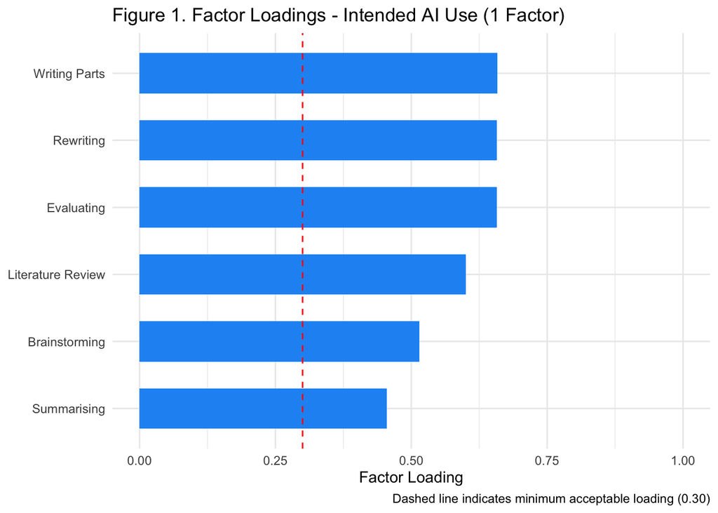

```r
# 1. Factor loading plot - AI Use (1 factor)
loadings_use_plot <- data.frame(
  Item = c("Brainstorming", "Literature Review", "Rewriting",
           "Evaluating", "Writing Parts", "Summarising"),
  Loading = c(0.515, 0.600, 0.657, 0.657, 0.658, 0.455)
)

ggplot(loadings_use_plot, aes(x = reorder(Item, Loading), y = Loading)) +
  geom_bar(stat = "identity", fill = "#2196F3", width = 0.6) +
  geom_hline(yintercept = 0.3, linetype = "dashed", colour = "red") +
  coord_flip() +
  labs(
    title = "Figure 1. Factor Loadings - Intended AI Use (1 Factor)",
    x = NULL,
    y = "Factor Loading",
    caption = "Dashed line indicates minimum acceptable loading (0.30)"
  ) +
  theme_minimal() +
  ylim(0, 1)
```

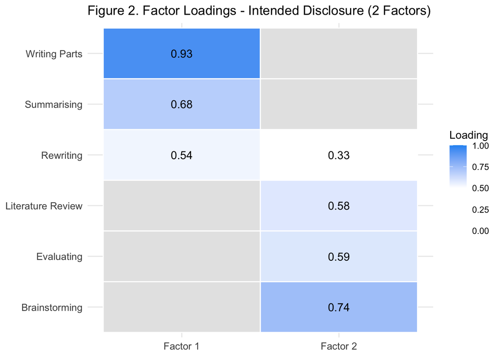

```r
# 2. Factor loading heatmap - AI Disclosure (2 factors)
loadings_disclosure_plot <- data.frame(
  Item = rep(c("Brainstorming", "Literature Review", "Rewriting",
               "Evaluating", "Writing Parts", "Summarising"), 2),
  Factor = rep(c("Factor 1", "Factor 2"), each = 6),
  Loading = c(NA, NA, 0.536, NA, 0.934, 0.683,
              0.742, 0.584, 0.333, 0.588, NA, NA)
)

ggplot(loadings_disclosure_plot, aes(x = Factor, y = Item, fill = Loading)) +
  geom_tile(colour = "white", size = 0.5) +
  geom_text(aes(label = ifelse(is.na(Loading), "", round(Loading, 2))),
            size = 4) +
  scale_fill_gradient2(low = "white", high = "#2196F3",
                       na.value = "grey90", midpoint = 0.5,
                       limits = c(0, 1)) +
  labs(
    title = "Figure 2. Factor Loadings - Intended Disclosure (2 Factors)",
    x = NULL,
    y = NULL,
    fill = "Loading"
  ) +
  theme_minimal() +
  theme(axis.text = element_text(size = 10))
```

### Cronbach’s Alpha for internal consistency

```r
# alpha > 0.70 is the accepted threshold for acceptable reliability

# AI use
alpha_use <- alpha(ai_use_items)
print(alpha_use$total)
```

```
##  raw_alpha std.alpha   G6(smc) average_r      S/N        ase     mean        sd
##   0.758721 0.7618573 0.7552309 0.3477667 3.199163 0.02643798 3.033167 0.8916308
##   median_r
##  0.3427141
```

```r
# AI disclosure
alpha_disclosure <- alpha(ai_disclosure_items)
print(alpha_disclosure$total)
```

```
##  raw_alpha std.alpha   G6(smc) average_r      S/N        ase     mean       sd
##  0.8221257 0.8245989 0.8263365 0.4393161 4.701218 0.01974063 2.364842 1.058354
##   median_r
##  0.4488031
```

### Composites

```r
# Single composite score as mean of all 6 items for each scale
# Justified by 1-factor EFA solution and acceptable Cronbach's alpha

df_primary <- df_primary %>%
  mutate(
    ai_use_composite = rowMeans(select(., ai_use_1:ai_use_6), na.rm = TRUE),
    ai_disclosure_composite = rowMeans(select(., ai_disclosure_1:ai_disclosure_6), na.rm = TRUE)
  )

#distributions
summary(df_primary$ai_use_composite)
```

```
##    Min. 1st Qu.  Median    Mean 3rd Qu.    Max.
##   1.000   2.500   3.000   3.033   3.667   5.000
```

```r
summary(df_primary$ai_disclosure_composite)
```

```
##    Min. 1st Qu.  Median    Mean 3rd Qu.    Max.
##   1.000   1.500   2.167   2.365   3.000   5.000
```

```r
# Means and SDs
df_primary %>%
  summarise(
    mean_use          = mean(ai_use_composite),
    sd_use            = sd(ai_use_composite),
    median_use        = median(ai_use_composite),
    mean_disclosure   = mean(ai_disclosure_composite),
    sd_disclosure     = sd(ai_disclosure_composite),
    median_disclosure = median(ai_disclosure_composite)
  )
```

```
## # A tibble: 1 × 6
##   mean_use sd_use median_use mean_disclosure sd_disclosure median_disclosure
##      <dbl>  <dbl>      <dbl>           <dbl>         <dbl>             <dbl>
## 1     3.03  0.892          3            2.36          1.06              2.17
```

### Cronbach’s Alpha for Subscales

```r
# Cronbach's alpha for each subscale
# Factor 1 — higher AIAS (writing parts, summarising, rewriting)
alpha_f1 <- alpha(df_primary %>%
                    select(ai_disclosure_5, ai_disclosure_6, ai_disclosure_3))
print(alpha_f1$total)
```

```
##  raw_alpha std.alpha   G6(smc) average_r      S/N        ase     mean       sd
##  0.8216634 0.8227104 0.7622052 0.6073549 4.640488 0.02196688 2.036484 1.200368
##   median_r
##  0.6318617
```

```r
# Factor 2 — lower AIAS (brainstorming, literature review, evaluating)
alpha_f2 <- alpha(df_primary %>%
                    select(ai_disclosure_1, ai_disclosure_2, ai_disclosure_4))
print(alpha_f2$total)
```

```
##  raw_alpha std.alpha   G6(smc) average_r      S/N        ase     mean       sd
##   0.710533 0.7109962 0.6232925 0.4505657 2.460162 0.03539155 2.693201 1.201094
##  median_r
##  0.450784
```

### Histogram

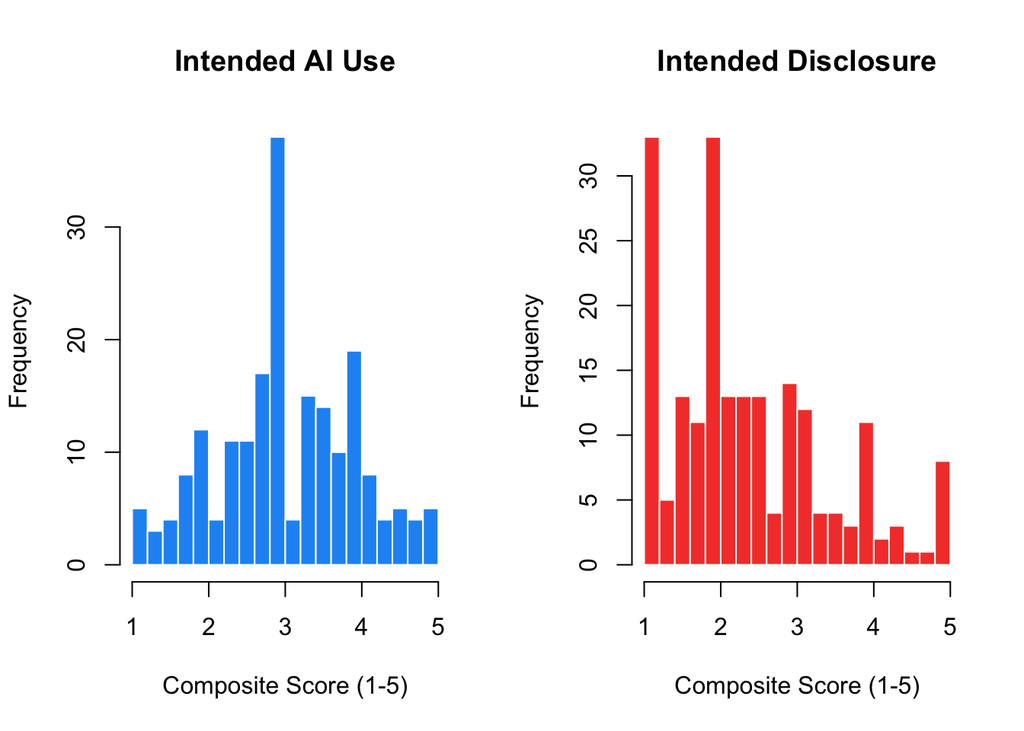

```r
#Histograms - distribution of composites
par(mfrow = c(1, 2))

hist(df_primary$ai_use_composite,
     main = "Intended AI Use",
     xlab = "Composite Score (1-5)",
     col = "#2196F3",
     border = "white",
     breaks = 15)

hist(df_primary$ai_disclosure_composite,
     main = "Intended Disclosure",
     xlab = "Composite Score (1-5)",
     col = "#F44336",
     border = "white",
     breaks = 15)
```

```r
par(mfrow = c(1, 1))
```

### Outliers check using Z-scores

```r
# Participants with |z| > 3.29 considered outliers (p < .001, two-tailed)
df_primary <- df_primary %>%
  mutate(
    z_ai_use = as.numeric(scale(ai_use_composite)),
    z_ai_disclosure = as.numeric(scale(ai_disclosure_composite))
  )

# Identify outliers
outliers <- df_primary %>%
  filter(abs(z_ai_use) > 3.29 | abs(z_ai_disclosure) > 3.29) %>%
  select(response_id, condition, ai_use_composite, z_ai_use,
         ai_disclosure_composite, z_ai_disclosure)

print(outliers)
```

```
## # A tibble: 0 × 6
## # ℹ 6 variables: response_id <chr>, condition <chr>, ai_use_composite <dbl>,
## #   z_ai_use <dbl>, ai_disclosure_composite <dbl>, z_ai_disclosure <dbl>
```

```r
nrow(outliers)
```

```
## [1] 0
```

## RESULT: No outliers.

### Assumptions

```r
# Shapiro-Wilk test - tests whether data significantly deviates from normal distribution. If p > .05 = normality holds, p < .05 = normality violated. Q-Q plots provide visual confirmation

# Shapiro-Wilk tests
shapiro.test(df_primary$ai_use_composite)
```

```
##
##  Shapiro-Wilk normality test
##
## data:  df_primary$ai_use_composite
## W = 0.9879, p-value = 0.08531
```

```r
shapiro.test(df_primary$ai_disclosure_composite)
```

```
##
##  Shapiro-Wilk normality test
##
## data:  df_primary$ai_disclosure_composite
## W = 0.93077, p-value = 3.655e-08
```

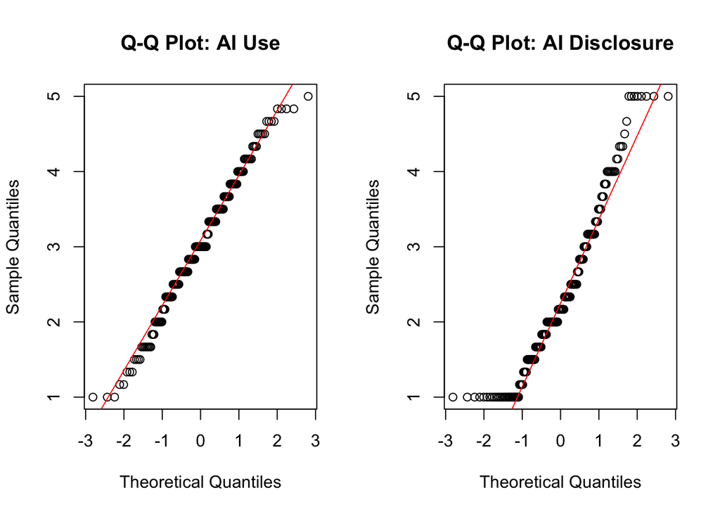

```r
# Q-Q plots
par(mfrow = c(1, 2))
qqnorm(df_primary$ai_use_composite, main = "Q-Q Plot: AI Use")
qqline(df_primary$ai_use_composite, col = "red")
qqnorm(df_primary$ai_disclosure_composite, main = "Q-Q Plot: AI Disclosure")
qqline(df_primary$ai_disclosure_composite, col = "red")
```

```r
par(mfrow = c(1, 1))
```

```r
# Skewness and kurtosis for composites
cat("=== AI Use Composite ===\n")
```

```
## === AI Use Composite ===
```

```r
cat("Skewness:", round(skewness(df_primary$ai_use_composite, na.rm = TRUE), 3), "\n")
```

```
## Skewness: -0.071
```

```r
cat("Kurtosis:", round(kurtosis(df_primary$ai_use_composite, na.rm = TRUE), 3), "\n")
```

```
## Kurtosis: 2.547
```

```r
cat("\n=== AI Disclosure Composite ===\n")
```

```
##
## === AI Disclosure Composite ===
```

```r
cat("Skewness:", round(skewness(df_primary$ai_disclosure_composite, na.rm = TRUE), 3), "\n")
```

```
## Skewness: 0.727
```

```r
cat("Kurtosis:", round(kurtosis(df_primary$ai_disclosure_composite, na.rm = TRUE), 3), "\n")
```

```
## Kurtosis: 2.889
```

### Manipulation Check

```r
# mancheck1: 1=hierarchical[AR], 2=reciprocal[EM], 3=merit-based[MP]
# mancheck2: 1=equals[EM], 2=institutional power[AR], 3=evaluation[MP]

mancheck_summary <- df_primary %>%
  group_by(condition) %>%
  summarise(
    mc1_hierarchical = mean(mancheck1_1, na.rm = TRUE),
    mc1_reciprocal   = mean(mancheck1_2, na.rm = TRUE),
    mc1_merit        = mean(mancheck1_3, na.rm = TRUE),
    mc2_equals       = mean(mancheck2_1, na.rm = TRUE),
    mc2_power        = mean(mancheck2_2, na.rm = TRUE),
    mc2_evaluation   = mean(mancheck2_3, na.rm = TRUE)
  )

mancheck_summary %>%
  gt() %>%
  tab_header(title = "Table 6. Manipulation Check Means by Condition") %>%
  cols_label(
    condition        = "Condition",
    mc1_hierarchical = "Hierarchical",
    mc1_reciprocal   = "Reciprocal",
    mc1_merit        = "Merit-based",
    mc2_equals       = "Equals",
    mc2_power        = "Institutional Power",
    mc2_evaluation   = "Evaluation"
  ) %>%
  tab_spanner(
    label = "Policy Perception (mancheck1)",
    columns = c(mc1_hierarchical, mc1_reciprocal, mc1_merit)
  ) %>%
  tab_spanner(
    label = "Declaration Perception (mancheck2)",
    columns = c(mc2_equals, mc2_power, mc2_evaluation)
  ) %>%
  fmt_number(decimals = 2)
```

Table 6. Manipulation Check Means by Condition

| Condition | Policy Perception (mancheck1) Hierarchical | Policy Perception (mancheck1) Reciprocal | Policy Perception (mancheck1) Merit-based | Declaration Perception (mancheck2) Equals | Declaration Perception (mancheck2) Institutional Power | Declaration Perception (mancheck2) Evaluation |
| --- | --- | --- | --- | --- | --- | --- |
| AR | 3.04 | 2.94 | 3.03 | 3.07 | 3.60 | 3.82 |
| EM | 2.94 | 3.30 | 2.91 | 3.49 | 3.27 | 3.90 |
| MP | 3.07 | 3.07 | 3.10 | 3.15 | 3.28 | 4.01 |

### ANOVA on manipulation check items - do condition means differ significantly on each item

```r
# mancheck1 - policy perception
anova_mc1_hierarchical <- aov(mancheck1_1 ~ condition, data = df_primary)
anova_mc1_reciprocal   <- aov(mancheck1_2 ~ condition, data = df_primary)
anova_mc1_merit        <- aov(mancheck1_3 ~ condition, data = df_primary)

# mancheck2 - declaration perception
anova_mc2_equals       <- aov(mancheck2_1 ~ condition, data = df_primary)
anova_mc2_power        <- aov(mancheck2_2 ~ condition, data = df_primary)
anova_mc2_evaluation   <- aov(mancheck2_3 ~ condition, data = df_primary)

# Print results
cat("=== Policy Perception (mancheck1) ===\n")
```

```
## === Policy Perception (mancheck1) ===
```

```r
cat("Hierarchical:\n");  print(summary(anova_mc1_hierarchical))
```

```
## Hierarchical:
```

```
##              Df Sum Sq Mean Sq F value Pr(>F)
## condition     2   0.67  0.3333    0.39  0.678
## Residuals   198 169.25  0.8548
```

```r
cat("Reciprocal:\n");    print(summary(anova_mc1_reciprocal))
```

```
## Reciprocal:
```

```
##              Df Sum Sq Mean Sq F value Pr(>F)
## condition     2   4.39  2.1940    2.85 0.0602 .
## Residuals   198 152.42  0.7698
## ---
## Signif. codes:  0 '***' 0.001 '**' 0.01 '*' 0.05 '.' 0.1 ' ' 1
```

```r
cat("Merit-based:\n");   print(summary(anova_mc1_merit))
```

```
## Merit-based:
```

```
##              Df Sum Sq Mean Sq F value Pr(>F)
## condition     2   1.28  0.6418   0.643  0.527
## Residuals   198 197.67  0.9983
```

```r
cat("\n=== Declaration Perception (mancheck2) ===\n")
```

```
##
## === Declaration Perception (mancheck2) ===
```

```r
cat("Equals:\n");               print(summary(anova_mc2_equals))
```

```
## Equals:
```

```
##              Df Sum Sq Mean Sq F value Pr(>F)
## condition     2   6.66   3.328   2.442 0.0896 .
## Residuals   198 269.88   1.363
## ---
## Signif. codes:  0 '***' 0.001 '**' 0.01 '*' 0.05 '.' 0.1 ' ' 1
```

```r
cat("Institutional Power:\n");  print(summary(anova_mc2_power))
```

```
## Institutional Power:
```

```
##              Df Sum Sq Mean Sq F value Pr(>F)
## condition     2   4.61   2.304   2.084  0.127
## Residuals   198 218.90   1.105
```

```r
cat("Evaluation:\n");           print(summary(anova_mc2_evaluation))
```

```
## Evaluation:
```

```
##              Df Sum Sq Mean Sq F value Pr(>F)
## condition     2   1.28  0.6418   0.734  0.481
## Residuals   198 173.10  0.8743
```

## Understanding the table

```r
library(gt)

mancheck_summary %>%
  gt() %>%
  tab_header(title = "Manipulation Check Means by Condition") %>%
  cols_label(
    condition        = "Condition",
    mc1_hierarchical = "Hierarchical",
    mc1_reciprocal   = "Reciprocal",
    mc1_merit        = "Merit-based",
    mc2_equals       = "Equals",
    mc2_power        = "Institutional Power",
    mc2_evaluation   = "Evaluation"
  ) %>%
  tab_spanner(
    label = "Policy Perception (mancheck1)",
    columns = c(mc1_hierarchical, mc1_reciprocal, mc1_merit)
  ) %>%
  tab_spanner(
    label = "Declaration Perception (mancheck2)",
    columns = c(mc2_equals, mc2_power, mc2_evaluation)
  ) %>%
  fmt_number(decimals = 2)
```

Manipulation Check Means by Condition

| Condition | Policy Perception (mancheck1) Hierarchical | Policy Perception (mancheck1) Reciprocal | Policy Perception (mancheck1) Merit-based | Declaration Perception (mancheck2) Equals | Declaration Perception (mancheck2) Institutional Power | Declaration Perception (mancheck2) Evaluation |
| --- | --- | --- | --- | --- | --- | --- |
| AR | 3.04 | 2.94 | 3.03 | 3.07 | 3.60 | 3.82 |
| EM | 2.94 | 3.30 | 2.91 | 3.49 | 3.27 | 3.90 |
| MP | 3.07 | 3.07 | 3.10 | 3.15 | 3.28 | 4.01 |

### Grouped bar chart - manipulation check means by condition and item

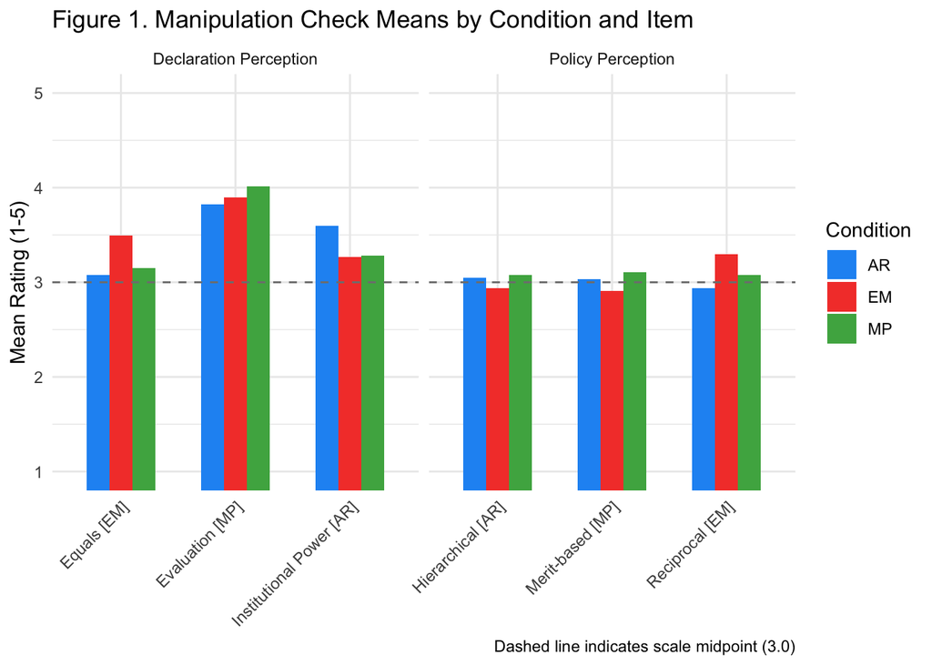

```r
mancheck_long <- mancheck_summary %>%
  mutate(condition = factor(condition, levels = c("AR", "EM", "MP"))) %>%
  pivot_longer(cols = -condition,
               names_to = "item",
               values_to = "mean") %>%
  mutate(
    check = case_when(
      item %in% c("mc1_hierarchical", "mc1_reciprocal", "mc1_merit") ~ "Policy Perception",
      TRUE ~ "Declaration Perception"
    ),
    item_label = case_when(
      item == "mc1_hierarchical" ~ "Hierarchical [AR]",
      item == "mc1_reciprocal"   ~ "Reciprocal [EM]",
      item == "mc1_merit"        ~ "Merit-based [MP]",
      item == "mc2_equals"       ~ "Equals [EM]",
      item == "mc2_power"        ~ "Institutional Power [AR]",
      item == "mc2_evaluation"   ~ "Evaluation [MP]"
    )
  )

ggplot(mancheck_long, aes(x = item_label, y = mean, fill = condition)) +
  geom_bar(stat = "identity", position = "dodge", width = 0.6) +
  geom_hline(yintercept = 3, linetype = "dashed", colour = "grey50") +
  facet_wrap(~check, scales = "free_x") +
  scale_fill_manual(values = c("AR" = "#2196F3", "EM" = "#F44336", "MP" = "#4CAF50")) +
  labs(
    title = "Figure 1. Manipulation Check Means by Condition and Item",
    x = NULL,
    y = "Mean Rating (1-5)",
    fill = "Condition",
    caption = "Dashed line indicates scale midpoint (3.0)"
  ) +
  theme_minimal() +
  theme(axis.text.x = element_text(angle = 45, hjust = 1)) +
  coord_cartesian(ylim = c(1, 5))
```

### Covariates - English Prof (recode - ordinal 1-4, higher = more proficient)

```r
# Treated as interval-level for parametric analysis
df_primary <- df_primary %>%
  mutate(english_proficiency = case_when(
    b2q4 == 1 ~ 4,  # Native speaker
    b2q4 == 2 ~ 3,  # Fluent non-native
    b2q4 == 3 ~ 2,  # Intermediate
    b2q4 == 4 ~ 1,  # Basic
    TRUE ~ NA_real_
  ))

table(df_primary$english_proficiency, useNA = "always")
```

```
##
##    2    3    4 <NA>
##    4   32  165    0
```

### UAI - check UAI in df_primary

```r
cat("NAs in UAI:", sum(is.na(df_primary$uai)), "\n")
```

```
## NAs in UAI: 2
```

```r
summary(df_primary$uai)
```

```
##    Min. 1st Qu.  Median    Mean 3rd Qu.    Max.    NA's
##   13.00   35.00   35.00   41.44   35.00   92.00       2
```

### Linearity Check

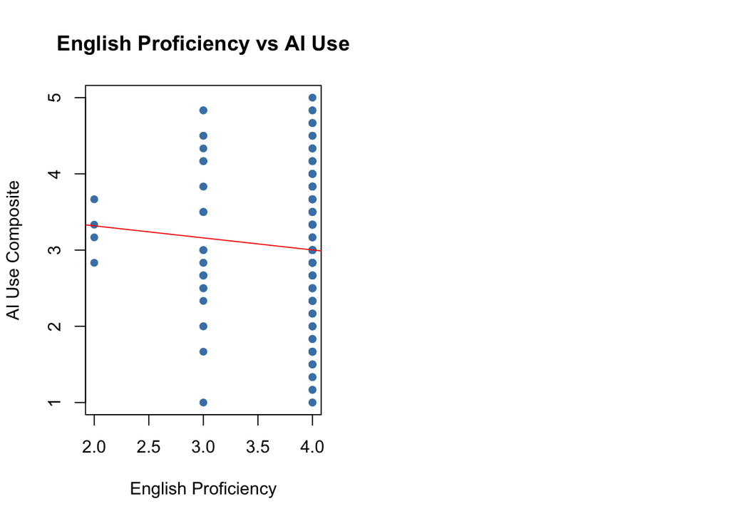

```r
# Visual inspection of scatterplots for continuous predictors vs DVs
# Checks whether relationships between covariates and outcomes are linear

# Linearity check - English Proficiency
par(mfrow = c(1, 2))

plot(df_primary$english_proficiency, df_primary$ai_use_composite,
     main = "English Proficiency vs AI Use",
     xlab = "English Proficiency", ylab = "AI Use Composite",
     pch = 16, col = "steelblue")
abline(lm(ai_use_composite ~ english_proficiency, data = df_primary), col = "red")
```

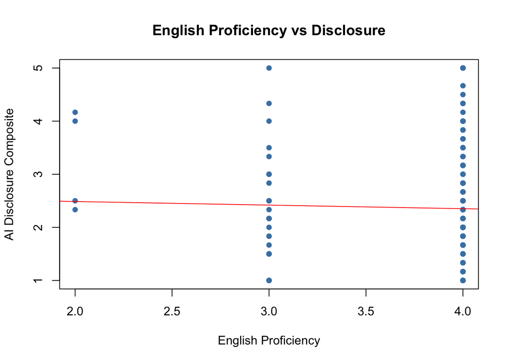

```r
plot(df_primary$english_proficiency, df_primary$ai_disclosure_composite,
     main = "English Proficiency vs Disclosure",
     xlab = "English Proficiency", ylab = "AI Disclosure Composite",
     pch = 16, col = "steelblue")
abline(lm(ai_disclosure_composite ~ english_proficiency, data = df_primary), col = "red")
```

```r
par(mfrow = c(1, 1))
```

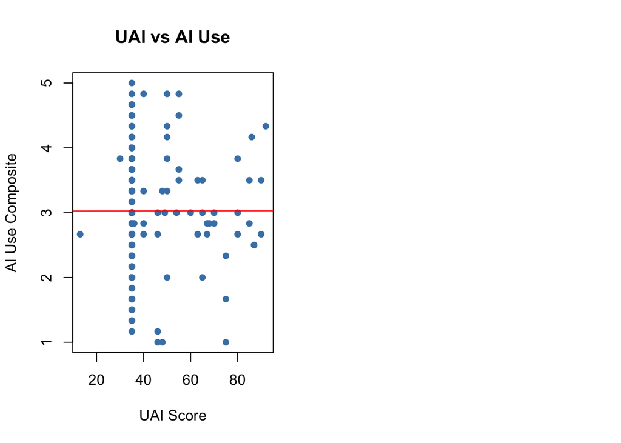

```r
# Linearity check - UAI
par(mfrow = c(1, 2))

plot(df_primary$uai, df_primary$ai_use_composite,
     main = "UAI vs AI Use",
     xlab = "UAI Score", ylab = "AI Use Composite",
     pch = 16, col = "steelblue")
abline(lm(ai_use_composite ~ uai, data = df_primary), col = "red")
```

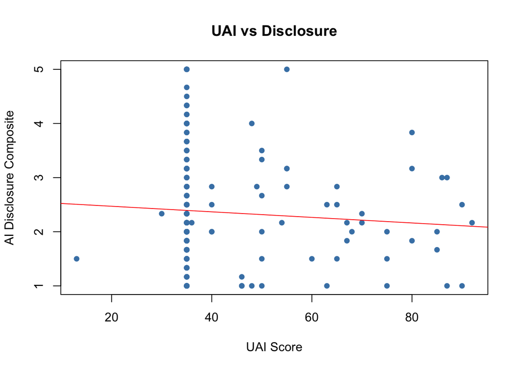

```r
plot(df_primary$uai, df_primary$ai_disclosure_composite,
     main = "UAI vs Disclosure",
     xlab = "UAI Score", ylab = "AI Disclosure Composite",
     pch = 16, col = "steelblue")
abline(lm(ai_disclosure_composite ~ uai, data = df_primary), col = "red")
```

```r
par(mfrow = c(1, 1))
```

### One-way ANOVA - Tests whether there are significant differences in means across the three

```r
# relational framing conditions (AR, EM, MP) for intended AI use and disclosure
# Omnibus test - does not test specific pairwise differences
# Addresses RQ1 (AI use) and RQ2 (disclosure)

df_primary <- df_primary %>%
  mutate(condition = factor(condition, levels = c("AR", "EM", "MP")))

# RQ1: AI use across conditions
anova_use <- aov(ai_use_composite ~ condition, data = df_primary)
summary(anova_use)
```

```
##              Df Sum Sq Mean Sq F value Pr(>F)
## condition     2   0.01  0.0068   0.008  0.992
## Residuals   198 158.99  0.8030
```

```r
# RQ2: AI disclosure across conditions
anova_disclosure <- aov(ai_disclosure_composite ~ condition, data = df_primary)
summary(anova_disclosure)
```

```
##              Df Sum Sq Mean Sq F value Pr(>F)
## condition     2   6.21   3.106   2.824 0.0618 .
## Residuals   198 217.81   1.100
## ---
## Signif. codes:  0 '***' 0.001 '**' 0.01 '*' 0.05 '.' 0.1 ' ' 1
```

```r
# Group means and SDs
df_primary %>%
  group_by(condition) %>%
  summarise(
    mean_use        = mean(ai_use_composite, na.rm = TRUE),
    sd_use          = sd(ai_use_composite, na.rm = TRUE),
    mean_disclosure = mean(ai_disclosure_composite, na.rm = TRUE),
    sd_disclosure   = sd(ai_disclosure_composite, na.rm = TRUE)
  )
```

```
## # A tibble: 3 × 5
##   condition mean_use sd_use mean_disclosure sd_disclosure
##   <fct>        <dbl>  <dbl>           <dbl>         <dbl>
## 1 AR            3.04  0.907            2.50          1.10
## 2 EM            3.02  0.825            2.12          1.00
## 3 MP            3.03  0.952            2.47          1.05
```

## Tukey’s

```r
# Only run for disclosure since AI use ANOVA was non-significant
tukey_disclosure <- TukeyHSD(anova_disclosure)
print(tukey_disclosure)
```

```
##   Tukey multiple comparisons of means
##     95% family-wise confidence level
##
## Fit: aov(formula = ai_disclosure_composite ~ condition, data = df_primary)
##
## $condition
##              diff         lwr       upr     p adj
## EM-AR -0.38805970 -0.81598430 0.0398649 0.0842096
## MP-AR -0.03233831 -0.46026291 0.3955863 0.9825979
## MP-EM  0.35572139 -0.07220321 0.7836460 0.1241680
```

## Regression model 1 (covariates)

```r
# Step 1 of hierarchical regression
# Tests whether English proficiency and UAI predict disclosure and AI use
model1_use <- lm(ai_use_composite ~ english_proficiency + uai,data = df_primary)
summary(model1_use)
```

```
##
## Call:
## lm(formula = ai_use_composite ~ english_proficiency + uai, data = df_primary)
##
## Residuals:
##      Min       1Q   Median       3Q      Max
## -2.07556 -0.52865 -0.01089  0.65578  1.98911
##
## Coefficients:
##                      Estimate Std. Error t value Pr(>|t|)
## (Intercept)          4.031903   0.864770   4.662 5.77e-06 ***
## english_proficiency -0.221048   0.185072  -1.194    0.234
## uai                 -0.003909   0.005538  -0.706    0.481
## ---
## Signif. codes:  0 '***' 0.001 '**' 0.01 '*' 0.05 '.' 0.1 ' ' 1
##
## Residual standard error: 0.8937 on 196 degrees of freedom
##   (2 observations deleted due to missingness)
## Multiple R-squared:  0.007226,   Adjusted R-squared:  -0.002904
## F-statistic: 0.7133 on 2 and 196 DF,  p-value: 0.4913
```

```r
model1_disclosure <- lm(ai_disclosure_composite ~ english_proficiency + uai, data = df_primary)
summary(model1_disclosure)
```

```
##
## Call:
## lm(formula = ai_disclosure_composite ~ english_proficiency +
##     uai, data = df_primary)
##
## Residuals:
##     Min      1Q  Median      3Q     Max
## -1.6203 -0.7883 -0.2102  0.7899  2.6232
##
## Coefficients:
##                      Estimate Std. Error t value Pr(>|t|)
## (Intercept)          3.682895   1.027807   3.583 0.000428 ***
## english_proficiency -0.243503   0.219964  -1.107 0.269645
## uai                 -0.009488   0.006582  -1.441 0.151045
## ---
## Signif. codes:  0 '***' 0.001 '**' 0.01 '*' 0.05 '.' 0.1 ' ' 1
##
## Residual standard error: 1.062 on 196 degrees of freedom
##   (2 observations deleted due to missingness)
## Multiple R-squared:  0.01097,    Adjusted R-squared:  0.000877
## F-statistic: 1.087 on 2 and 196 DF,  p-value: 0.3393
```

### Regression - Model 2 (Covariates + Condition) - AR as reference category is pre-registered

```r
model2_use <- lm(ai_use_composite ~ english_proficiency + uai + condition, data = df_primary)
summary(model2_use)
```

```
##
## Call:
## lm(formula = ai_use_composite ~ english_proficiency + uai + condition,
##     data = df_primary)
##
## Residuals:
##      Min       1Q   Median       3Q      Max
## -2.08332 -0.53253 -0.01631  0.64883  1.98369
##
## Coefficients:
##                      Estimate Std. Error t value Pr(>|t|)
## (Intercept)          4.050896   0.878623   4.611 7.28e-06 ***
## english_proficiency -0.223076   0.187741  -1.188    0.236
## uai                 -0.003978   0.005607  -0.709    0.479
## conditionEM         -0.021977   0.155907  -0.141    0.888
## conditionMP         -0.003055   0.157273  -0.019    0.985
## ---
## Signif. codes:  0 '***' 0.001 '**' 0.01 '*' 0.05 '.' 0.1 ' ' 1
##
## Residual standard error: 0.8983 on 194 degrees of freedom
##   (2 observations deleted due to missingness)
## Multiple R-squared:  0.007345,   Adjusted R-squared:  -0.01312
## F-statistic: 0.3589 on 4 and 194 DF,  p-value: 0.8376
```

```r
model2_disclosure <- lm(ai_disclosure_composite ~ english_proficiency + uai + condition, data = df_primary)
summary(model2_disclosure)
```

```
##
## Call:
## lm(formula = ai_disclosure_composite ~ english_proficiency +
##     uai + condition, data = df_primary)
##
## Residuals:
##     Min      1Q  Median      3Q     Max
## -1.5161 -0.7827 -0.1719  0.6614  2.8839
##
## Coefficients:
##                     Estimate Std. Error t value Pr(>|t|)
## (Intercept)          4.05381    1.02801   3.943 0.000112 ***
## english_proficiency -0.28863    0.21966  -1.314 0.190400
## uai                 -0.01095    0.00656  -1.669 0.096803 .
## conditionEM         -0.40006    0.18241  -2.193 0.029485 *
## conditionMP         -0.01091    0.18401  -0.059 0.952790
## ---
## Signif. codes:  0 '***' 0.001 '**' 0.01 '*' 0.05 '.' 0.1 ' ' 1
##
## Residual standard error: 1.051 on 194 degrees of freedom
##   (2 observations deleted due to missingness)
## Multiple R-squared:  0.04165,    Adjusted R-squared:  0.02189
## F-statistic: 2.108 on 4 and 194 DF,  p-value: 0.08135
```

# VIF check - more predictors means more potential for multicollinearity

```r
# VIF - multicollinearity between predictors (VIF < 10 acceptable)
# Breusch-Pagan - homoscedasticity of residuals (p > .05 = assumption holds)

# VIF
cat("=== VIF - AI Disclosure Model ===\n")
```

```
## === VIF - AI Disclosure Model ===
```

```r
vif(model2_disclosure)
```

```
##                         GVIF Df GVIF^(1/(2*Df))
## english_proficiency 1.577869  1        1.256132
## uai                 1.571890  1        1.253750
## condition           1.021681  2        1.005377
```

```r
cat("\n=== VIF - AI Use Model ===\n")
```

```
##
## === VIF - AI Use Model ===
```

```r
vif(model2_use)
```

```
##                         GVIF Df GVIF^(1/(2*Df))
## english_proficiency 1.577869  1        1.256132
## uai                 1.571890  1        1.253750
## condition           1.021681  2        1.005377
```

```r
# Breusch-Pagan
cat("\n=== Breusch-Pagan - AI Disclosure Model ===\n")
```

```
##
## === Breusch-Pagan - AI Disclosure Model ===
```

```r
bptest(model2_disclosure)
```

```
##
##  studentized Breusch-Pagan test
##
## data:  model2_disclosure
## BP = 1.6928, df = 4, p-value = 0.792
```

```r
cat("\n=== Breusch-Pagan - AI Use Model ===\n")
```

```
##
## === Breusch-Pagan - AI Use Model ===
```

```r
bptest(model2_use)
```

```
##
##  studentized Breusch-Pagan test
##
## data:  model2_use
## BP = 1.6538, df = 4, p-value = 0.7991
```

### Residuals vs fitted plot

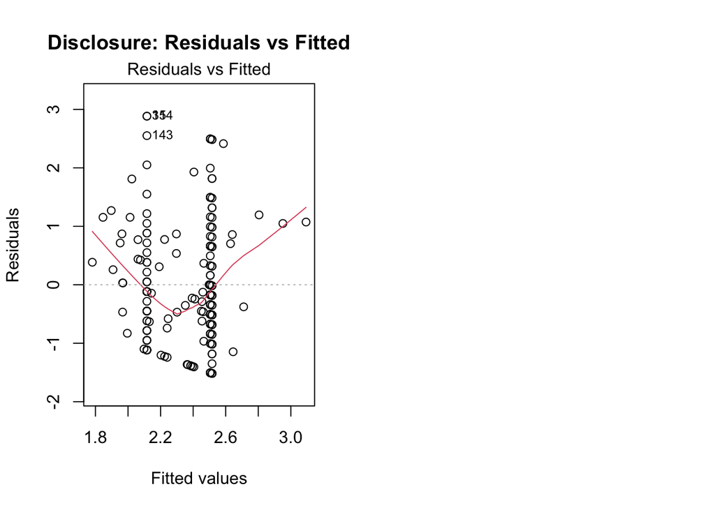

```r
# Residuals vs fitted plots for both models
par(mfrow = c(1, 2))

plot(model2_disclosure, which = 1,
     main = "Disclosure: Residuals vs Fitted")
```

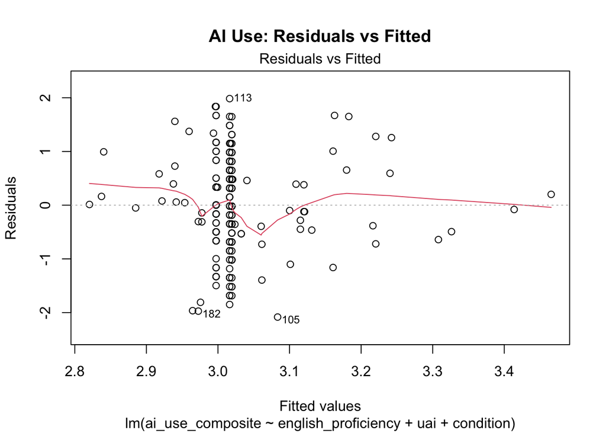

```r
plot(model2_use, which = 1,
     main = "AI Use: Residuals vs Fitted")
```

```r
par(mfrow = c(1, 1))
```

### Shapiro Wilk - normality of residuals - Model 2

```r
# Shapiro-Wilk on residuals from Model 2
# Tests normality of residuals after fitting the regression model

cat("=== Shapiro-Wilk on Residuals - AI Disclosure Model ===\n")
```

```
## === Shapiro-Wilk on Residuals - AI Disclosure Model ===
```

```r
shapiro.test(residuals(model2_disclosure))
```

```
##
##  Shapiro-Wilk normality test
##
## data:  residuals(model2_disclosure)
## W = 0.9488, p-value = 1.531e-06
```

```r
cat("\n=== Shapiro-Wilk on Residuals - AI Use Model ===\n")
```

```
##
## === Shapiro-Wilk on Residuals - AI Use Model ===
```

```r
shapiro.test(residuals(model2_use))
```

```
##
##  Shapiro-Wilk normality test
##
## data:  residuals(model2_use)
## W = 0.99053, p-value = 0.2165
```

## Bootstrapping

```r
# 5000 samples to account for non-normal distribution of ai_disclosure
# AR as reference category (pre-registered)
boot_ar <- function(data, indices) {
  d <- data[indices, ]
  fit <- lm(ai_disclosure_composite ~ english_proficiency + uai + condition,
            data = d)
  return(coef(fit))
}

set.seed(123)
boot_ar_results <- boot(data = df_primary, statistic = boot_ar, R = 5000)

# CIs for each coefficient
boot.ci(boot_ar_results, type = "perc", index = 1) # intercept
```

```
## BOOTSTRAP CONFIDENCE INTERVAL CALCULATIONS
## Based on 5000 bootstrap replicates
##
## CALL :
## boot.ci(boot.out = boot_ar_results, type = "perc", index = 1)
##
## Intervals :
## Level     Percentile
## 95%   ( 1.601,  5.979 )
## Calculations and Intervals on Original Scale
```

```r
boot.ci(boot_ar_results, type = "perc", index = 2) # english proficiency
```

```
## BOOTSTRAP CONFIDENCE INTERVAL CALCULATIONS
## Based on 5000 bootstrap replicates
##
## CALL :
## boot.ci(boot.out = boot_ar_results, type = "perc", index = 2)
##
## Intervals :
## Level     Percentile
## 95%   (-0.6959,  0.2262 )
## Calculations and Intervals on Original Scale
```

```r
boot.ci(boot_ar_results, type = "perc", index = 3) # UAI
```

```
## BOOTSTRAP CONFIDENCE INTERVAL CALCULATIONS
## Based on 5000 bootstrap replicates
##
## CALL :
## boot.ci(boot.out = boot_ar_results, type = "perc", index = 3)
##
## Intervals :
## Level     Percentile
## 95%   (-0.0241,  0.0019 )
## Calculations and Intervals on Original Scale
```

```r
boot.ci(boot_ar_results, type = "perc", index = 4) # EM vs AR
```

```
## BOOTSTRAP CONFIDENCE INTERVAL CALCULATIONS
## Based on 5000 bootstrap replicates
##
## CALL :
## boot.ci(boot.out = boot_ar_results, type = "perc", index = 4)
##
## Intervals :
## Level     Percentile
## 95%   (-0.7498, -0.0331 )
## Calculations and Intervals on Original Scale
```

```r
boot.ci(boot_ar_results, type = "perc", index = 5) # MP vs AR
```

```
## BOOTSTRAP CONFIDENCE INTERVAL CALCULATIONS
## Based on 5000 bootstrap replicates
##
## CALL :
## boot.ci(boot.out = boot_ar_results, type = "perc", index = 5)
##
## Intervals :
## Level     Percentile
## 95%   (-0.377,  0.348 )
## Calculations and Intervals on Original Scale
```

### Supplementary analysis - EM as reference category

```r
# EM as reference category to test AR vs EM and MP vs EM

df_primary <- df_primary %>%
  mutate(condition_em_ref = factor(condition, levels = c("EM", "AR", "MP")))

model2_disclosure_em <- lm(ai_disclosure_composite ~ english_proficiency + uai + condition_em_ref, data = df_primary)
summary(model2_disclosure_em)
```

```
##
## Call:
## lm(formula = ai_disclosure_composite ~ english_proficiency +
##     uai + condition_em_ref, data = df_primary)
##
## Residuals:
##     Min      1Q  Median      3Q     Max
## -1.5161 -0.7827 -0.1719  0.6614  2.8839
##
## Coefficients:
##                     Estimate Std. Error t value Pr(>|t|)
## (Intercept)          3.65374    1.02278   3.572 0.000446 ***
## english_proficiency -0.28863    0.21966  -1.314 0.190400
## uai                 -0.01095    0.00656  -1.669 0.096803 .
## condition_em_refAR   0.40006    0.18241   2.193 0.029485 *
## condition_em_refMP   0.38916    0.18402   2.115 0.035725 *
## ---
## Signif. codes:  0 '***' 0.001 '**' 0.01 '*' 0.05 '.' 0.1 ' ' 1
##
## Residual standard error: 1.051 on 194 degrees of freedom
##   (2 observations deleted due to missingness)
## Multiple R-squared:  0.04165,    Adjusted R-squared:  0.02189
## F-statistic: 2.108 on 4 and 194 DF,  p-value: 0.08135
```

### Bootstrapping - EM as reference

```r
#Bootstrapped CIs - EM reference
# 5,000 samples to account for non-normal residuals in ai_disclosure

boot_em <- function(data, indices) {
  d <- data[indices, ]
  fit <- lm(ai_disclosure_composite ~ english_proficiency + uai +
              condition_em_ref, data = d)
  return(coef(fit))
}

set.seed(123)
boot_em_results <- boot(data = df_primary, statistic = boot_em, R = 5000)

boot.ci(boot_em_results, type = "perc", index = 1) # intercept
```

```
## BOOTSTRAP CONFIDENCE INTERVAL CALCULATIONS
## Based on 5000 bootstrap replicates
##
## CALL :
## boot.ci(boot.out = boot_em_results, type = "perc", index = 1)
##
## Intervals :
## Level     Percentile
## 95%   ( 1.260,  5.632 )
## Calculations and Intervals on Original Scale
```

```r
boot.ci(boot_em_results, type = "perc", index = 2) # english proficiency
```

```
## BOOTSTRAP CONFIDENCE INTERVAL CALCULATIONS
## Based on 5000 bootstrap replicates
##
## CALL :
## boot.ci(boot.out = boot_em_results, type = "perc", index = 2)
##
## Intervals :
## Level     Percentile
## 95%   (-0.6959,  0.2262 )
## Calculations and Intervals on Original Scale
```

```r
boot.ci(boot_em_results, type = "perc", index = 3) # UAI
```

```
## BOOTSTRAP CONFIDENCE INTERVAL CALCULATIONS
## Based on 5000 bootstrap replicates
##
## CALL :
## boot.ci(boot.out = boot_em_results, type = "perc", index = 3)
##
## Intervals :
## Level     Percentile
## 95%   (-0.0241,  0.0019 )
## Calculations and Intervals on Original Scale
```

```r
boot.ci(boot_em_results, type = "perc", index = 4) # AR vs EM
```

```
## BOOTSTRAP CONFIDENCE INTERVAL CALCULATIONS
## Based on 5000 bootstrap replicates
##
## CALL :
## boot.ci(boot.out = boot_em_results, type = "perc", index = 4)
##
## Intervals :
## Level     Percentile
## 95%   ( 0.0331,  0.7498 )
## Calculations and Intervals on Original Scale
```

```r
boot.ci(boot_em_results, type = "perc", index = 5) # MP vs EM
```

```
## BOOTSTRAP CONFIDENCE INTERVAL CALCULATIONS
## Based on 5000 bootstrap replicates
##
## CALL :
## boot.ci(boot.out = boot_em_results, type = "perc", index = 5)
##
## Intervals :
## Level     Percentile
## 95%   ( 0.0292,  0.7458 )
## Calculations and Intervals on Original Scale
```

```r
# Mixed ANOVA for manipulation check - Policy Perception (mancheck1)
# Within-subject factor: relational dimension (hierarchical, reciprocal, merit)
# Between-subject factor: condition (AR, EM, MP)

library(tidyr)
library(dplyr)

# Reshape to long format
mancheck_long_mixed <- df_primary %>%
  select(response_id, condition, mancheck1_1, mancheck1_2, mancheck1_3) %>%
  pivot_longer(cols = c(mancheck1_1, mancheck1_2, mancheck1_3),
               names_to = "dimension",
               values_to = "rating") %>%
  mutate(dimension = case_when(
    dimension == "mancheck1_1" ~ "Hierarchical",
    dimension == "mancheck1_2" ~ "Reciprocal",
    dimension == "mancheck1_3" ~ "Merit-based"
  ))

# Mixed ANOVA
if (!requireNamespace("ez", quietly = TRUE)) {
  install.packages("ez", repos = "https://cran.rstudio.com/")
}
library(ez)
mixed_anova_mc1 <- ezANOVA(
  data = mancheck_long_mixed,
  dv = rating,
  wid = response_id,
  within = dimension,
  between = condition,
  type = 3,
  return_aov = TRUE
)
print(mixed_anova_mc1)
```

```
## $ANOVA
##                Effect DFn DFd         F          p p<.05         ges
## 2           condition   2 198 0.2436869 0.78396771       0.001231064
## 3           dimension   2 396 0.7775731 0.46022017       0.001956797
## 4 condition:dimension   4 396 2.1756850 0.07103854       0.010852811
##
## $`Mauchly's Test for Sphericity`
##                Effect         W           p p<.05
## 3           dimension 0.9404077 0.002353126     *
## 4 condition:dimension 0.9404077 0.002353126     *
##
## $`Sphericity Corrections`
##                Effect       GGe      p[GG] p[GG]<.05       HFe      p[HF]
## 3           dimension 0.9437593 0.45353730           0.9525558 0.45460944
## 4 condition:dimension 0.9437593 0.07508766           0.9525558 0.07443871
##   p[HF]<.05
## 3
## 4
##
## $aov
##
## Call:
## aov(formula = formula(aov_formula), data = data)
##
## Grand Mean: 3.046434
##
## Stratum 1: response_id
##
## Terms:
##                 condition Residuals
## Sum of Squares    0.64013 260.05970
## Deg. of Freedom         2       198
##
## Residual standard error: 1.146051
## 4 out of 6 effects not estimable
## Estimated effects may be unbalanced
##
## Stratum 2: response_id:dimension
##
## Terms:
##                 dimension condition:dimension Residuals
## Sum of Squares    1.01824             5.69818 259.28358
## Deg. of Freedom         2                   4       396
##
## Residual standard error: 0.8091703
## Estimated effects may be unbalanced
```

```r
# Mixed ANOVA for manipulation check - Declaration Perception (mancheck2)
# Within-subject factor: relational dimension (equals, institutional power, evaluation)
# Between-subject factor: condition (AR, EM, MP)

mancheck_long_mixed2 <- df_primary %>%
  select(response_id, condition, mancheck2_1, mancheck2_2, mancheck2_3) %>%
  pivot_longer(cols = c(mancheck2_1, mancheck2_2, mancheck2_3),
               names_to = "dimension",
               values_to = "rating") %>%
  mutate(dimension = case_when(
    dimension == "mancheck2_1" ~ "Equals",
    dimension == "mancheck2_2" ~ "Institutional Power",
    dimension == "mancheck2_3" ~ "Evaluation"
  ))

# Mixed ANOVA
mixed_anova_mc2 <- ezANOVA(
  data = mancheck_long_mixed2,
  dv = rating,
  wid = response_id,
  within = dimension,
  between = condition,
  type = 3,
  return_aov = TRUE
)
print(mixed_anova_mc2)
```

```
## $ANOVA
##                Effect DFn DFd          F            p p<.05          ges
## 2           condition   2 198  0.2139703 8.075588e-01       0.0008161426
## 3           dimension   2 396 24.1654422 1.252448e-10     * 0.0705656054
## 4 condition:dimension   4 396  2.8869019 2.231254e-02     * 0.0178169773
##
## $`Mauchly's Test for Sphericity`
##                Effect         W            p p<.05
## 3           dimension 0.8607285 3.839902e-07     *
## 4 condition:dimension 0.8607285 3.839902e-07     *
##
## $`Sphericity Corrections`
##                Effect       GGe        p[GG] p[GG]<.05       HFe        p[HF]
## 3           dimension 0.8777539 1.298303e-09         * 0.8849829 1.130474e-09
## 4 condition:dimension 0.8777539 2.812459e-02         * 0.8849829 2.774074e-02
##   p[HF]<.05
## 3         *
## 4         *
##
## $aov
##
## Call:
## aov(formula = formula(aov_formula), data = data)
##
## Grand Mean: 3.510779
##
## Stratum 1: response_id
##
## Terms:
##                 condition Residuals
## Sum of Squares    0.54063 250.13930
## Deg. of Freedom         2       198
##
## Residual standard error: 1.123979
## 4 out of 6 effects not estimable
## Estimated effects may be unbalanced
##
## Stratum 2: response_id:dimension
##
## Terms:
##                 dimension condition:dimension Residuals
## Sum of Squares    50.2521             12.0066  411.7413
## Deg. of Freedom         2                   4       396
##
## Residual standard error: 1.019682
## Estimated effects may be unbalanced
```

```r
# Step 3: Simple effects - Policy Perception (mancheck1)
# Test whether each condition rated its matched item relatively highest

# Policy perception simple effects by condition
library(broom)
mc1_simple <- mancheck_long_mixed %>%
  group_by(condition) %>%
  do(tidy(aov(rating ~ dimension, data = .))) %>%
  filter(term == "dimension")

print(mc1_simple)
```

```
## # A tibble: 3 × 7
## # Groups:   condition [3]
##   condition term         df  sumsq meansq statistic p.value
##   <fct>     <chr>     <dbl>  <dbl>  <dbl>     <dbl>   <dbl>
## 1 AR        dimension     2 0.428  0.214     0.215   0.806
## 2 EM        dimension     2 6.25   3.12      3.34    0.0375
## 3 MP        dimension     2 0.0398 0.0199    0.0287  0.972
```

```r
# Pairwise comparisons within each condition for policy perception
mc1_pairwise <- mancheck_long_mixed %>%
  group_by(condition) %>%
  do({
    pairwise.t.test(.$rating, .$dimension,
                    paired = TRUE,
                    p.adjust.method = "bonferroni") %>%
      tidy()
  })

print(mc1_pairwise)
```

```
## # A tibble: 9 × 4
## # Groups:   condition [3]
##   condition group1      group2       p.value
##   <fct>     <chr>       <chr>          <dbl>
## 1 AR        Merit-based Hierarchical  1
## 2 AR        Reciprocal  Hierarchical  1
## 3 AR        Reciprocal  Merit-based   1
## 4 EM        Merit-based Hierarchical  1
## 5 EM        Reciprocal  Hierarchical  0.0457
## 6 EM        Reciprocal  Merit-based   0.0466
## 7 MP        Merit-based Hierarchical  1
## 8 MP        Reciprocal  Hierarchical  1
## 9 MP        Reciprocal  Merit-based   1
```

```r
# Step 3: Simple effects - Declaration Perception (mancheck2)
mc2_simple <- mancheck_long_mixed2 %>%
  group_by(condition) %>%
  do(tidy(aov(rating ~ dimension, data = .))) %>%
  filter(term == "dimension")

print(mc2_simple)
```

```
## # A tibble: 3 × 7
## # Groups:   condition [3]
##   condition term         df sumsq meansq statistic    p.value
##   <fct>     <chr>     <dbl> <dbl>  <dbl>     <dbl>      <dbl>
## 1 AR        dimension     2  19.7   9.83      7.76 0.000568
## 2 EM        dimension     2  13.5   6.76      6.43 0.00197
## 3 MP        dimension     2  29.1  14.5      14.2  0.00000176
```

```r
mc2_pairwise <- mancheck_long_mixed2 %>%
  group_by(condition) %>%
  do({
    pairwise.t.test(.$rating, .$dimension,
                    paired = TRUE,
                    p.adjust.method = "bonferroni") %>%
      tidy()
  })

print(mc2_pairwise)
```

```
## # A tibble: 9 × 4
## # Groups:   condition [3]
##   condition group1              group2         p.value
##   <fct>     <chr>               <chr>            <dbl>
## 1 AR        Evaluation          Equals     0.0000329
## 2 AR        Institutional Power Equals     0.0490
## 3 AR        Institutional Power Evaluation 0.646
## 4 EM        Evaluation          Equals     0.0488
## 5 EM        Institutional Power Equals     0.888
## 6 EM        Institutional Power Evaluation 0.000230
## 7 MP        Evaluation          Equals     0.000000269
## 8 MP        Institutional Power Equals     1
## 9 MP        Institutional Power Evaluation 0.0000655
```

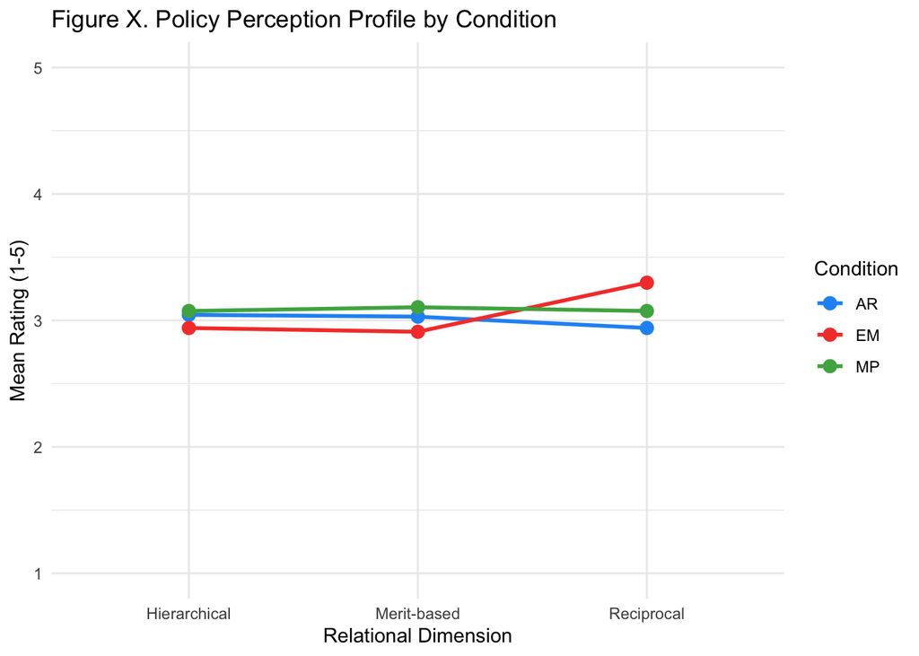

```r
# Step 4: Profile plots
library(ggplot2)

# Policy perception profile plot
mc1_means <- mancheck_long_mixed %>%
  group_by(condition, dimension) %>%
  summarise(mean_rating = mean(rating, na.rm = TRUE), .groups = "drop")

ggplot(mc1_means, aes(x = dimension, y = mean_rating,
                       group = condition, colour = condition)) +
  geom_line(linewidth = 1) +
  geom_point(size = 3) +
  scale_colour_manual(values = c("AR" = "#2196F3", "EM" = "#F44336", "MP" = "#4CAF50")) +
  labs(
    title = "Figure X. Policy Perception Profile by Condition",
    x = "Relational Dimension",
    y = "Mean Rating (1-5)",
    colour = "Condition"
  ) +
  theme_minimal() +
  coord_cartesian(ylim = c(1, 5))
```

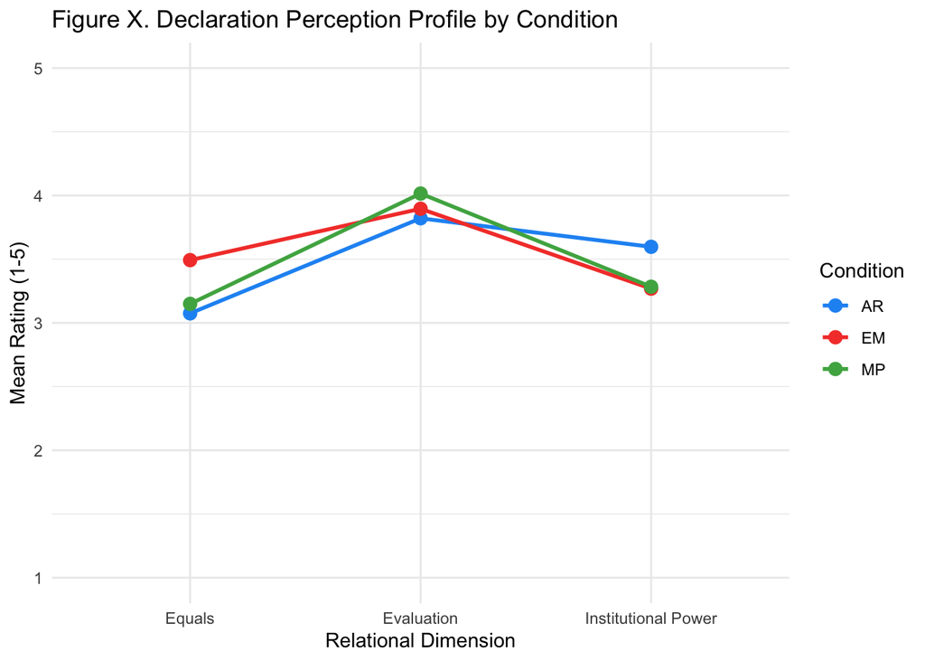

```r
# Declaration perception profile plot
mc2_means <- mancheck_long_mixed2 %>%
  group_by(condition, dimension) %>%
  summarise(mean_rating = mean(rating, na.rm = TRUE), .groups = "drop")

ggplot(mc2_means, aes(x = dimension, y = mean_rating,
                       group = condition, colour = condition)) +
  geom_line(linewidth = 1) +
  geom_point(size = 3) +
  scale_colour_manual(values = c("AR" = "#2196F3", "EM" = "#F44336", "MP" = "#4CAF50")) +
  labs(
    title = "Figure X. Declaration Perception Profile by Condition",
    x = "Relational Dimension",
    y = "Mean Rating (1-5)",
    colour = "Condition"
  ) +
  theme_minimal() +
  coord_cartesian(ylim = c(1, 5))
```

### Manipulation Check - t-test

```r
# Manipulation check t-tests
# Comparing conditions on each item separately
# Uncorrected p values reported (manipulation check, not primary hypothesis test)
# Directional predictions: EM should rate reciprocal highest,
# AR should rate hierarchical highest, MP should rate merit highest

# Policy Perception (mancheck1)
cat("=== Policy Perception (mancheck1) ===\n")
```

```
## === Policy Perception (mancheck1) ===
```

```r
# Hierarchical item [AR condition item]
cat("\nHierarchical item:\n")
```

```
##
## Hierarchical item:
```

```r
cat("EM vs AR:\n"); print(t.test(mancheck1_1 ~ condition,
       data = df_primary %>% filter(condition %in% c("EM", "AR"))))
```

```
## EM vs AR:
```

```
##
##  Welch Two Sample t-test
##
## data:  mancheck1_1 by condition
## t = 0.60788, df = 131.99, p-value = 0.5443
## alternative hypothesis: true difference in means between group AR and group EM is not equal to 0
## 95 percent confidence interval:
##  -0.2355037  0.4444589
## sample estimates:
## mean in group AR mean in group EM
##         3.044776         2.940299
```

```r
cat("MP vs AR:\n"); print(t.test(mancheck1_1 ~ condition,
       data = df_primary %>% filter(condition %in% c("MP", "AR"))))
```

```
## MP vs AR:
```

```
##
##  Welch Two Sample t-test
##
## data:  mancheck1_1 by condition
## t = -0.19512, df = 124.03, p-value = 0.8456
## alternative hypothesis: true difference in means between group AR and group MP is not equal to 0
## 95 percent confidence interval:
##  -0.3326477  0.2729462
## sample estimates:
## mean in group AR mean in group MP
##         3.044776         3.074627
```

```r
cat("EM vs MP:\n"); print(t.test(mancheck1_1 ~ condition,
       data = df_primary %>% filter(condition %in% c("EM", "MP"))))
```

```
## EM vs MP:
```

```
##
##  Welch Two Sample t-test
##
## data:  mancheck1_1 by condition
## t = -0.87428, df = 123.65, p-value = 0.3837
## alternative hypothesis: true difference in means between group EM and group MP is not equal to 0
## 95 percent confidence interval:
##  -0.4384418  0.1697851
## sample estimates:
## mean in group EM mean in group MP
##         2.940299         3.074627
```

```r
# Reciprocal item [EM condition item]
cat("\nReciprocal item:\n")
```

```
##
## Reciprocal item:
```

```r
cat("EM vs AR:\n"); print(t.test(mancheck1_2 ~ condition,
       data = df_primary %>% filter(condition %in% c("EM", "AR"))))
```

```
## EM vs AR:
```

```
##
##  Welch Two Sample t-test
##
## data:  mancheck1_2 by condition
## t = -2.2943, df = 130.45, p-value = 0.02337
## alternative hypothesis: true difference in means between group AR and group EM is not equal to 0
## 95 percent confidence interval:
##  -0.66708025 -0.04933766
## sample estimates:
## mean in group AR mean in group EM
##         2.940299         3.298507
```

```r
cat("MP vs AR:\n"); print(t.test(mancheck1_2 ~ condition,
       data = df_primary %>% filter(condition %in% c("MP", "AR"))))
```

```
## MP vs AR:
```

```
##
##  Welch Two Sample t-test
##
## data:  mancheck1_2 by condition
## t = -0.87428, df = 129.28, p-value = 0.3836
## alternative hypothesis: true difference in means between group AR and group MP is not equal to 0
## 95 percent confidence interval:
##  -0.4383108  0.1696541
## sample estimates:
## mean in group AR mean in group MP
##         2.940299         3.074627
```

```r
cat("EM vs MP:\n"); print(t.test(mancheck1_2 ~ condition,
       data = df_primary %>% filter(condition %in% c("EM", "MP"))))
```

```
## EM vs MP:
```

```
##
##  Welch Two Sample t-test
##
## data:  mancheck1_2 by condition
## t = 1.5466, df = 131.82, p-value = 0.1243
## alternative hypothesis: true difference in means between group EM and group MP is not equal to 0
## 95 percent confidence interval:
##  -0.06245971  0.51022091
## sample estimates:
## mean in group EM mean in group MP
##         3.298507         3.074627
```

```r
# Merit-based item [MP condition item]
cat("\nMerit-based item:\n")
```

```
##
## Merit-based item:
```

```r
cat("EM vs AR:\n"); print(t.test(mancheck1_3 ~ condition,
       data = df_primary %>% filter(condition %in% c("EM", "AR"))))
```

```
## EM vs AR:
```

```
##
##  Welch Two Sample t-test
##
## data:  mancheck1_3 by condition
## t = 0.66305, df = 132, p-value = 0.5085
## alternative hypothesis: true difference in means between group AR and group EM is not equal to 0
## 95 percent confidence interval:
##  -0.2368166  0.4756225
## sample estimates:
## mean in group AR mean in group EM
##         3.029851         2.910448
```

```r
cat("MP vs AR:\n"); print(t.test(mancheck1_3 ~ condition,
       data = df_primary %>% filter(condition %in% c("MP", "AR"))))
```

```
## MP vs AR:
```

```
##
##  Welch Two Sample t-test
##
## data:  mancheck1_3 by condition
## t = -0.44173, df = 129.46, p-value = 0.6594
## alternative hypothesis: true difference in means between group AR and group MP is not equal to 0
## 95 percent confidence interval:
##  -0.4088700  0.2596163
## sample estimates:
## mean in group AR mean in group MP
##         3.029851         3.104478
```

```r
cat("EM vs MP:\n"); print(t.test(mancheck1_3 ~ condition,
       data = df_primary %>% filter(condition %in% c("EM", "MP"))))
```

```
## EM vs MP:
```

```
##
##  Welch Two Sample t-test
##
## data:  mancheck1_3 by condition
## t = -1.1507, df = 129.58, p-value = 0.252
## alternative hypothesis: true difference in means between group EM and group MP is not equal to 0
## 95 percent confidence interval:
##  -0.5276371  0.1395774
## sample estimates:
## mean in group EM mean in group MP
##         2.910448         3.104478
```

```r
# Declaration Perception (mancheck2)
cat("\n=== Declaration Perception (mancheck2) ===\n")
```

```
##
## === Declaration Perception (mancheck2) ===
```

```r
# Equals item [EM condition item]
cat("\nEquals item:\n")
```

```
##
## Equals item:
```

```r
cat("EM vs AR:\n"); print(t.test(mancheck2_1 ~ condition,
       data = df_primary %>% filter(condition %in% c("EM", "AR"))))
```

```
## EM vs AR:
```

```
##
##  Welch Two Sample t-test
##
## data:  mancheck2_1 by condition
## t = -2.0195, df = 132, p-value = 0.04546
## alternative hypothesis: true difference in means between group AR and group EM is not equal to 0
## 95 percent confidence interval:
##  -0.827263285 -0.008557611
## sample estimates:
## mean in group AR mean in group EM
##         3.074627         3.492537
```

```r
cat("MP vs AR:\n"); print(t.test(mancheck2_1 ~ condition,
       data = df_primary %>% filter(condition %in% c("MP", "AR"))))
```

```
## MP vs AR:
```

```
##
##  Welch Two Sample t-test
##
## data:  mancheck2_1 by condition
## t = -0.37499, df = 131.15, p-value = 0.7083
## alternative hypothesis: true difference in means between group AR and group MP is not equal to 0
## 95 percent confidence interval:
##  -0.4683132  0.3190595
## sample estimates:
## mean in group AR mean in group MP
##         3.074627         3.149254
```

```r
cat("EM vs MP:\n"); print(t.test(mancheck2_1 ~ condition,
       data = df_primary %>% filter(condition %in% c("EM", "MP"))))
```

```
## EM vs MP:
```

```
##
##  Welch Two Sample t-test
##
## data:  mancheck2_1 by condition
## t = 1.7244, df = 131.13, p-value = 0.087
## alternative hypothesis: true difference in means between group EM and group MP is not equal to 0
## 95 percent confidence interval:
##  -0.05053733  0.73710450
## sample estimates:
## mean in group EM mean in group MP
##         3.492537         3.149254
```

```r
# Institutional Power item [AR condition item]
cat("\nInstitutional Power item:\n")
```

```
##
## Institutional Power item:
```

```r
cat("EM vs AR:\n"); print(t.test(mancheck2_2 ~ condition,
       data = df_primary %>% filter(condition %in% c("EM", "AR"))))
```

```
## EM vs AR:
```

```
##
##  Welch Two Sample t-test
##
## data:  mancheck2_2 by condition
## t = 1.7992, df = 131.51, p-value = 0.07428
## alternative hypothesis: true difference in means between group AR and group EM is not equal to 0
## 95 percent confidence interval:
##  -0.03266128  0.68937769
## sample estimates:
## mean in group AR mean in group EM
##         3.597015         3.268657
```

```r
cat("MP vs AR:\n"); print(t.test(mancheck2_2 ~ condition,
       data = df_primary %>% filter(condition %in% c("MP", "AR"))))
```

```
## MP vs AR:
```

```
##
##  Welch Two Sample t-test
##
## data:  mancheck2_2 by condition
## t = 1.7033, df = 131.75, p-value = 0.09087
## alternative hypothesis: true difference in means between group AR and group MP is not equal to 0
## 95 percent confidence interval:
##  -0.05056816  0.67743383
## sample estimates:
## mean in group AR mean in group MP
##         3.597015         3.283582
```

```r
cat("EM vs MP:\n"); print(t.test(mancheck2_2 ~ condition,
       data = df_primary %>% filter(condition %in% c("EM", "MP"))))
```

```
## EM vs MP:
```

```
##
##  Welch Two Sample t-test
##
## data:  mancheck2_2 by condition
## t = -0.083651, df = 131.96, p-value = 0.9335
## alternative hypothesis: true difference in means between group EM and group MP is not equal to 0
## 95 percent confidence interval:
##  -0.3678682  0.3380174
## sample estimates:
## mean in group EM mean in group MP
##         3.268657         3.283582
```

```r
# Evaluation item [MP condition item]
cat("\nEvaluation item:\n")
```

```
##
## Evaluation item:
```

```r
cat("EM vs AR:\n"); print(t.test(mancheck2_3 ~ condition,
       data = df_primary %>% filter(condition %in% c("EM", "AR"))))
```

```
## EM vs AR:
```

```
##
##  Welch Two Sample t-test
##
## data:  mancheck2_3 by condition
## t = -0.44907, df = 122.72, p-value = 0.6542
## alternative hypothesis: true difference in means between group AR and group EM is not equal to 0
## 95 percent confidence interval:
##  -0.4035806  0.2543269
## sample estimates:
## mean in group AR mean in group EM
##         3.820896         3.895522
```

```r
cat("MP vs AR:\n"); print(t.test(mancheck2_3 ~ condition,
       data = df_primary %>% filter(condition %in% c("MP", "AR"))))
```

```
## MP vs AR:
```

```
##
##  Welch Two Sample t-test
##
## data:  mancheck2_3 by condition
## t = -1.1367, df = 126.5, p-value = 0.2578
## alternative hypothesis: true difference in means between group AR and group MP is not equal to 0
## 95 percent confidence interval:
##  -0.5318081  0.1437484
## sample estimates:
## mean in group AR mean in group MP
##         3.820896         4.014925
```

```r
cat("EM vs MP:\n"); print(t.test(mancheck2_3 ~ condition,
       data = df_primary %>% filter(condition %in% c("EM", "MP"))))
```

```
## EM vs MP:
```

```
##
##  Welch Two Sample t-test
##
## data:  mancheck2_3 by condition
## t = -0.81355, df = 131.35, p-value = 0.4174
## alternative hypothesis: true difference in means between group EM and group MP is not equal to 0
## 95 percent confidence interval:
##  -0.4097381  0.1709321
## sample estimates:
## mean in group EM mean in group MP
##         3.895522         4.014925
```

### Hypothesis 3 - Disclosure gap - RQ3

```r
# Composite gap = ai_use_composite - ai_disclosure_composite
# Item level gap = ai_use item - ai_disclosure item for each pair
# Positive gap = participants intend to use AI more than they disclose

df_primary <- df_primary %>%
  mutate(
    disclosure_gap_composite = ai_use_composite - ai_disclosure_composite,
    gap_1 = ai_use_1 - ai_disclosure_1, # brainstorming
    gap_2 = ai_use_2 - ai_disclosure_2, # literature review
    gap_3 = ai_use_3 - ai_disclosure_3, # rewriting
    gap_4 = ai_use_4 - ai_disclosure_4, # evaluating
    gap_5 = ai_use_5 - ai_disclosure_5, # writing parts
    gap_6 = ai_use_6 - ai_disclosure_6  # summarising
  )

# Composite gap summary
summary(df_primary$disclosure_gap_composite)
```

```
##    Min. 1st Qu.  Median    Mean 3rd Qu.    Max.
## -3.5000  0.0000  0.6667  0.6683  1.5000  3.5000
```

```r
# Item level gaps
item_gaps <- df_primary %>%
  summarise(
    brainstorming     = mean(gap_1, na.rm = TRUE),
    literature_review = mean(gap_2, na.rm = TRUE),
    rewriting         = mean(gap_3, na.rm = TRUE),
    evaluating        = mean(gap_4, na.rm = TRUE),
    writing_parts     = mean(gap_5, na.rm = TRUE),
    summarising       = mean(gap_6, na.rm = TRUE)
  ) %>%
  pivot_longer(everything(), names_to = "item", values_to = "mean_gap") %>%
  arrange(desc(mean_gap))

print(item_gaps)
```

```
## # A tibble: 6 × 2
##   item              mean_gap
##   <chr>                <dbl>
## 1 evaluating           0.980
## 2 brainstorming        0.861
## 3 summarising          0.756
## 4 literature_review    0.716
## 5 rewriting            0.532
## 6 writing_parts        0.164
```

### ANOVA intention-disclosure gap

```r
anova_gap <- aov(disclosure_gap_composite ~ condition, data = df_primary)
summary(anova_gap)
```

```
##              Df Sum Sq Mean Sq F value Pr(>F)
## condition     2   5.67   2.836   1.851   0.16
## Residuals   198 303.44   1.532
```

```r
# Group means and SDs by condition
df_primary %>%
  group_by(condition) %>%
  summarise(
    mean_gap = mean(disclosure_gap_composite, na.rm = TRUE),
    sd_gap   = sd(disclosure_gap_composite, na.rm = TRUE)
  )
```

```
## # A tibble: 3 × 3
##   condition mean_gap sd_gap
##   <fct>        <dbl>  <dbl>
## 1 AR           0.537   1.36
## 2 EM           0.905   1.23
## 3 MP           0.562   1.11
```

```r
t.test(df_primary$ai_use_composite,
       df_primary$ai_disclosure_composite,
       paired = TRUE)
```

```
##
##  Paired t-test
##
## data:  df_primary$ai_use_composite and df_primary$ai_disclosure_composite
## t = 7.6216, df = 200, p-value = 9.858e-13
## alternative hypothesis: true mean difference is not equal to 0
## 95 percent confidence interval:
##  0.4954119 0.8412382
## sample estimates:
## mean difference
##        0.668325
```

### Use-Disclosure Gap Across Conditions

```r
# Disclosure gap by condition
df_primary %>%
  group_by(condition) %>%
  summarise(
    mean_gap = mean(disclosure_gap_composite, na.rm = TRUE),
    sd_gap   = sd(disclosure_gap_composite, na.rm = TRUE)
  )
```

```
## # A tibble: 3 × 3
##   condition mean_gap sd_gap
##   <fct>        <dbl>  <dbl>
## 1 AR           0.537   1.36
## 2 EM           0.905   1.23
## 3 MP           0.562   1.11
```

```r
# ANOVA
anova_gap <- aov(disclosure_gap_composite ~ condition, data = df_primary)
summary(anova_gap)
```

```
##              Df Sum Sq Mean Sq F value Pr(>F)
## condition     2   5.67   2.836   1.851   0.16
## Residuals   198 303.44   1.532
```

### USE-DISCLOSURE Gap Diagram

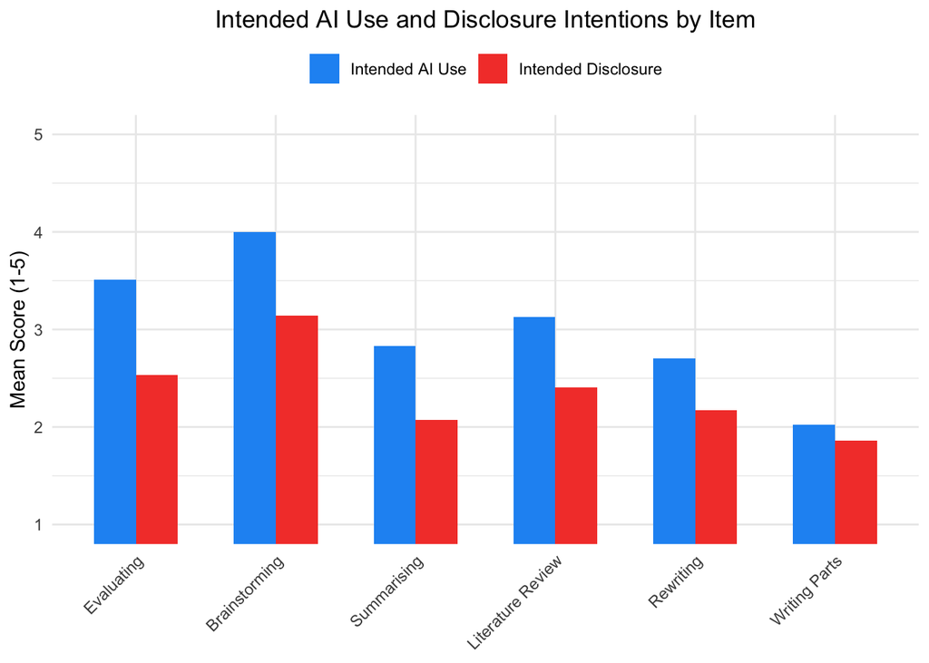

```r
# Disclosure gap visualisations

# Data preparation
item_gap_data <- data.frame(
  item = c("Brainstorming", "Literature Review", "Rewriting",
           "Evaluating", "Writing Parts", "Summarising"),
  ai_use = c(mean(df_primary$ai_use_1), mean(df_primary$ai_use_2),
             mean(df_primary$ai_use_3), mean(df_primary$ai_use_4),
             mean(df_primary$ai_use_5), mean(df_primary$ai_use_6)),
  ai_disclosure = c(mean(df_primary$ai_disclosure_1), mean(df_primary$ai_disclosure_2),
                    mean(df_primary$ai_disclosure_3), mean(df_primary$ai_disclosure_4),
                    mean(df_primary$ai_disclosure_5), mean(df_primary$ai_disclosure_6))
) %>%
  mutate(gap = ai_use - ai_disclosure) %>%
  arrange(desc(gap))

# 1. Paired bar chart
item_gap_long <- item_gap_data %>%
  pivot_longer(cols = c(ai_use, ai_disclosure),
               names_to = "measure",
               values_to = "mean") %>%
  mutate(measure = case_when(
    measure == "ai_use" ~ "Intended AI Use",
    measure == "ai_disclosure" ~ "Intended Disclosure"
  ),
  item = factor(item, levels = item_gap_data$item))

ggplot(item_gap_long, aes(x = item, y = mean, fill = measure)) +
  geom_bar(stat = "identity", position = "dodge", width = 0.6) +
  scale_fill_manual(values = c("Intended AI Use" = "#2196F3",
                                "Intended Disclosure" = "#F44336")) +
  labs(
    title = "Intended AI Use and Disclosure Intentions by Item",
    x = NULL,
    y = "Mean Score (1-5)",
    fill = NULL,
  ) +
 theme_minimal() +
  theme(axis.text.x = element_text(angle = 45, hjust = 1),
        legend.position = "top",
        plot.title = element_text(hjust = 0.5)) +
  coord_cartesian(ylim = c(1, 5))
```

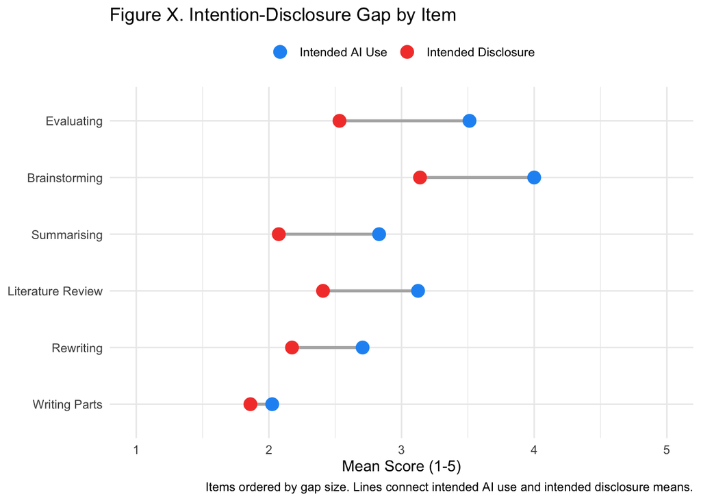

```r
# 2. Dot plot with connecting lines
ggplot(item_gap_data, aes(y = reorder(item, gap))) +
  geom_segment(aes(x = ai_disclosure, xend = ai_use,
                   yend = reorder(item, gap)),
               colour = "grey70", linewidth = 1) +
  geom_point(aes(x = ai_use, colour = "Intended AI Use"), size = 4) +
  geom_point(aes(x = ai_disclosure, colour = "Intended Disclosure"), size = 4) +
  scale_colour_manual(values = c("Intended AI Use" = "#2196F3",
                                  "Intended Disclosure" = "#F44336")) +
  labs(
    title = "Figure X. Intention-Disclosure Gap by Item",
    x = "Mean Score (1-5)",
    y = NULL,
    colour = NULL,
    caption = "Items ordered by gap size. Lines connect intended AI use and intended disclosure means."
  ) +
  theme_minimal() +
  theme(legend.position = "top") +
  coord_cartesian(xlim = c(1, 5))
```

### GAP Across Conditions

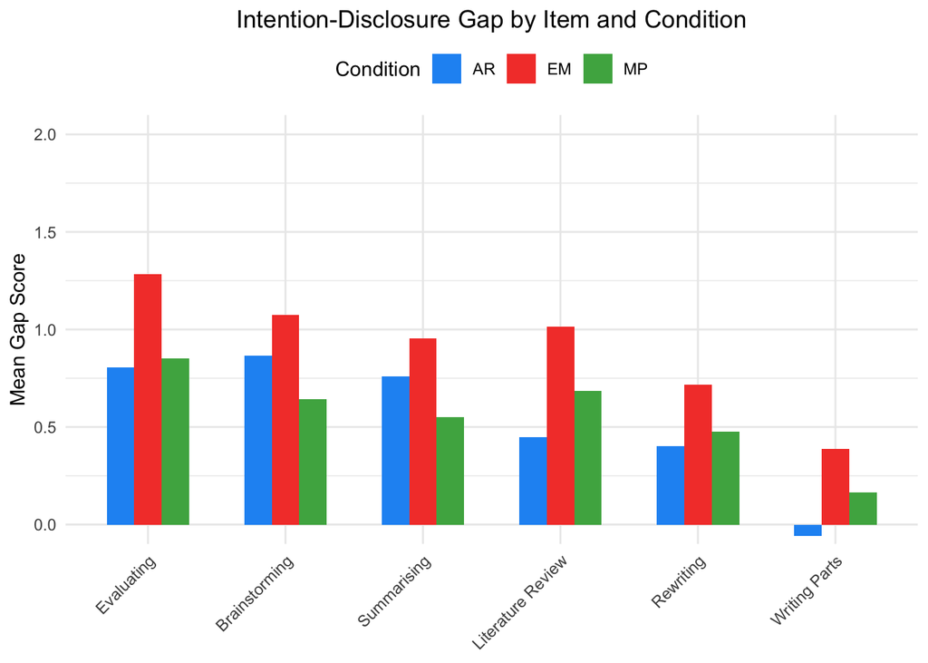

```r
# Disclosure gap across items by condition
item_gap_condition <- df_primary %>%
  group_by(condition) %>%
  summarise(
    brainstorming     = mean(gap_1, na.rm = TRUE),
    literature_review = mean(gap_2, na.rm = TRUE),
    rewriting         = mean(gap_3, na.rm = TRUE),
    evaluating        = mean(gap_4, na.rm = TRUE),
    writing_parts     = mean(gap_5, na.rm = TRUE),
    summarising       = mean(gap_6, na.rm = TRUE)
  ) %>%
  pivot_longer(cols = -condition,
               names_to = "item",
               values_to = "mean_gap") %>%
  mutate(
    item = case_when(
      item == "brainstorming"     ~ "Brainstorming",
      item == "literature_review" ~ "Literature Review",
      item == "rewriting"         ~ "Rewriting",
      item == "evaluating"        ~ "Evaluating",
      item == "writing_parts"     ~ "Writing Parts",
      item == "summarising"       ~ "Summarising"
    ),
    item = factor(item, levels = c("Evaluating", "Brainstorming",
                                    "Summarising", "Literature Review",
                                    "Rewriting", "Writing Parts"))
  )

ggplot(item_gap_condition, aes(x = item, y = mean_gap, fill = condition)) +
  geom_bar(stat = "identity", position = "dodge", width = 0.6) +
  scale_fill_manual(values = c("AR" = "#2196F3",
                                "EM" = "#F44336",
                                "MP" = "#4CAF50")) +
  labs(
    title = "Intention-Disclosure Gap by Item and Condition",
    x = NULL,
    y = "Mean Gap Score",
    fill = "Condition",
  ) +
  theme_minimal() +
  theme(
    axis.text.x = element_text(angle = 45, hjust = 1),
    legend.position = "top",
    plot.title = element_text(hjust = 0.5)
  ) +
  coord_cartesian(ylim = c(0, 2))
```

### Effect sizes

```r
# Cohen's f2 for regression models - Cohen (1988): small = .02, medium = .15, large = .35

library(effectsize)

# Cohen's f2 for regression models
# f2 = R2 / (1 - R2)
cat("=== Cohen's f2 - Model 1 AI Use ===\n")
```

```
## === Cohen's f2 - Model 1 AI Use ===
```

```r
cat("f2 =", round(summary(model1_use)$r.squared /
                  (1 - summary(model1_use)$r.squared), 3), "\n")
```

```
## f2 = 0.007
```

```r
cat("\n=== Cohen's f2 - Model 2 AI Use ===\n")
```

```
##
## === Cohen's f2 - Model 2 AI Use ===
```

```r
cat("f2 =", round(summary(model2_use)$r.squared /
                  (1 - summary(model2_use)$r.squared), 3), "\n")
```

```
## f2 = 0.007
```

```r
cat("\n=== Cohen's f2 - Model 1 Disclosure ===\n")
```

```
##
## === Cohen's f2 - Model 1 Disclosure ===
```

```r
cat("f2 =", round(summary(model1_disclosure)$r.squared /
                  (1 - summary(model1_disclosure)$r.squared), 3), "\n")
```

```
## f2 = 0.011
```

```r
cat("\n=== Cohen's f2 - Model 2 Disclosure ===\n")
```

```
##
## === Cohen's f2 - Model 2 Disclosure ===
```

```r
cat("f2 =", round(summary(model2_disclosure)$r.squared /
                  (1 - summary(model2_disclosure)$r.squared), 3), "\n")
```

```
## f2 = 0.043
```

### QUAL CODING***

```r
# Check original column names that correspond to Q1_4, Q1_5, Q6
names(df_primary) %>% grep("q1_4|q1_5|q6", ., value = TRUE, ignore.case = TRUE)
```

```
##  [1] "mpq1_4" "mpq1_5" "mpq6"   "emq1_4" "emq1_5" "emq6"   "arq1_4" "arq1_5"
##  [9] "arq6"   "b2q6"
```

```r
#Coalesce open-ended text columns
df_primary <- df_primary %>%
  mutate(
    ai_prompt      = coalesce(mpq1_4, emq1_4, arq1_4),
    ai_declaration = coalesce(mpq1_5, emq1_5, arq1_5),
    ai_free_text   = coalesce(mpq6, emq6, arq6)
  )

# Check coalesced columns
df_primary %>%
  select(response_id, condition, ai_prompt, ai_declaration, ai_free_text) %>%
  filter(!is.na(ai_prompt) | !is.na(ai_declaration) | !is.na(ai_free_text)) %>%
  head(10)
```

```
## # A tibble: 10 × 5
##    response_id       condition ai_prompt             ai_declaration ai_free_text
##    <chr>             <fct>     <chr>                 <chr>          <chr>
##  1 R_1OvRjgRdd3trTJy EM        Give me an interesti… What are some… I utilised …
##  2 R_2D7TvH1qw8XxFcg AR        Can you describe wha… Can you give … AI has been…
##  3 R_eb4sccI0vaccsdr MP        use three frameworks… use three fra… I used AI t…
##  4 R_2rPGU1UGMu6Z3EP MP        Give me a contempora… Using the the… I used Chat…
##  5 R_T6eX13rIYuOhC0x AR        Based on the informa… Given the aca… I want to f…
##  6 R_PZCXzRyvWD6xgEF AR        List me 10 contempor… What theoreti… Throughout …
##  7 R_vSv9jvn0IGyXHR7 EM        Plan my 3000 word es… Choose the be… I have used…
##  8 R_1IpcDFXlXDl0H5K AR        please summarise the… make sure the… i would lik…
##  9 R_12FSyeiQ2pcqYSh EM        Which issues can I w… What are the … In the comp…
## 10 R_6fb5SiS18L0o46J EM        What would be an app… Do you have a… Generative …
```

```r
#Export qualitative coding CSV
qual_export <- df_primary %>%
  select(response_id, condition, ai_prompt, ai_declaration, ai_free_text)

# Check how many have responses
cat("Participants with ai_prompt:", sum(!is.na(qual_export$ai_prompt)), "\n")
```

```
## Participants with ai_prompt: 201
```

```r
cat("Participants with ai_declaration:", sum(!is.na(qual_export$ai_declaration)), "\n")
```

```
## Participants with ai_declaration: 201
```

```r
cat("Participants with ai_free_text:", sum(!is.na(qual_export$ai_free_text)), "\n")
```

```
## Participants with ai_free_text: 201
```

```r
# Export
write.csv(qual_export, "qual_coding.csv", row.names = FALSE)
cat("Exported", nrow(qual_export), "rows to qual_coding.csv\n")
```

```
## Exported 201 rows to qual_coding.csv
```

### Qualitative Coding

```r
# Qualitative coding analysis
# Load data
qual_df <- read.csv("~/Desktop/ Qual Analysis.csv",
                    header = FALSE,
                    col.names = c("condition", "ai_use_1", "ai_use_2",
                                  "disclosure_1", "disclosure_2"))
```

```r
# Clean
qual_df <- qual_df %>%
  filter(condition %in% c("AR", "EM", "MP")) %>%
  mutate(across(everything(), ~trimws(tolower(.))))

# Check
cat("Total rows:", nrow(qual_df), "\n")
```

```
## Total rows: 201
```

```r
table(qual_df$condition)
```

```
##
## ar em mp
## 67 67 67
```

```r
# Define tasks
tasks <- c("brainstorming", "literature review", "evaluating",
           "rewriting", "summarising", "writing parts")

# Overall AI use frequency
ai_use_all <- c(qual_df$ai_use_1, qual_df$ai_use_2)
ai_use_freq <- table(ai_use_all[ai_use_all %in% tasks])
cat("\n=== AI USE FREQUENCY ===\n")
```

```
##
## === AI USE FREQUENCY ===
```

```r
print(sort(ai_use_freq, decreasing = TRUE))
```

```
##
##     brainstorming     writing parts literature review        evaluating
##               163               125                50                33
##         rewriting       summarising
##                11                 6
```

```r
# Overall disclosure frequency
disc_all <- c(qual_df$disclosure_1, qual_df$disclosure_2)
disc_freq <- table(disc_all[disc_all %in% tasks])
cat("\n=== DISCLOSURE FREQUENCY ===\n")
```

```
##
## === DISCLOSURE FREQUENCY ===
```

```r
print(sort(disc_freq, decreasing = TRUE))
```

```
##
##     brainstorming        evaluating literature review         rewriting
##               125                42                41                36
##       summarising     writing parts
##                23                 3
```

```r
# Gap
cat("\n=== GAP (use - disclosure) ===\n")
```

```
##
## === GAP (use - disclosure) ===
```

```r
gap_df <- data.frame(
  task = tasks,
  ai_use = as.numeric(ai_use_freq[tasks]),
  disclosure = as.numeric(disc_freq[tasks])
) %>%
  mutate(
    ai_use = replace_na(ai_use, 0),
    disclosure = replace_na(disclosure, 0),
    gap = ai_use - disclosure
  ) %>%
  arrange(desc(gap))
print(gap_df)
```

```
##                task ai_use disclosure gap
## 1     writing parts    125          3 122
## 2     brainstorming    163        125  38
## 3 literature review     50         41   9
## 4        evaluating     33         42  -9
## 5       summarising      6         23 -17
## 6         rewriting     11         36 -25
```

```r
#condition analysis
tasks <- c("brainstorming", "literature review", "evaluating",
           "rewriting", "summarising", "writing parts")

for (cond in c("AR", "EM", "MP")) {
  cond_df <- qual_df %>% filter(condition == cond)
  cat("\n", cond, "— AI Use:\n")
  cond_use <- c(cond_df$ai_use_1, cond_df$ai_use_2)
  print(sort(table(cond_use[cond_use %in% tasks]), decreasing = TRUE))
  cat(cond, "— Disclosure:\n")
  cond_disc <- c(cond_df$disclosure_1, cond_df$disclosure_2)
  print(sort(table(cond_disc[cond_disc %in% tasks]), decreasing = TRUE))
}
```

```
##
##  AR — AI Use:
## integer(0)
## AR — Disclosure:
## integer(0)
##
##  EM — AI Use:
## integer(0)
## EM — Disclosure:
## integer(0)
##
##  MP — AI Use:
## integer(0)
## MP — Disclosure:
## integer(0)
```

### Exploratory Analysis

```r
# Create ai_disclosure subscales
df_primary <- df_primary %>%
  mutate(
    # Factor 1 - higher AIAS levels (substitutive)
    # writing parts, summarising, rewriting
    disclosure_f1 = rowMeans(select(., ai_disclosure_5,
                                       ai_disclosure_6,
                                       ai_disclosure_3), na.rm = TRUE),

    # Factor 2 - lower AIAS levels (assistive)
    # brainstorming, literature review, evaluating
    disclosure_f2 = rowMeans(select(., ai_disclosure_1,
                                       ai_disclosure_2,
                                       ai_disclosure_4), na.rm = TRUE)
  )
```

```r
# Regression for Factor 1 (substitutive disclosure)
model_f1 <- lm(disclosure_f1 ~ english_proficiency + uai + condition,
               data = df_primary)
summary(model_f1)
```

```
##
## Call:
## lm(formula = disclosure_f1 ~ english_proficiency + uai + condition,
##     data = df_primary)
##
## Residuals:
##     Min      1Q  Median      3Q     Max
## -1.2625 -0.7997 -0.2625  0.5831  3.2099
##
## Coefficients:
##                      Estimate Std. Error t value Pr(>|t|)
## (Intercept)          4.318579   1.158641   3.727 0.000254 ***
## english_proficiency -0.385787   0.247574  -1.558 0.120800
## uai                 -0.014656   0.007394  -1.982 0.048867 *
## conditionEM         -0.472404   0.205595  -2.298 0.022643 *
## conditionMP         -0.147427   0.207397  -0.711 0.478032
## ---
## Signif. codes:  0 '***' 0.001 '**' 0.01 '*' 0.05 '.' 0.1 ' ' 1
##
## Residual standard error: 1.185 on 194 degrees of freedom
##   (2 observations deleted due to missingness)
## Multiple R-squared:  0.04496,    Adjusted R-squared:  0.02527
## F-statistic: 2.283 on 4 and 194 DF,  p-value: 0.06183
```

```r
# Regression for Factor 2 (assistive disclosure)
model_f2 <- lm(disclosure_f2 ~ english_proficiency + uai + condition,
               data = df_primary)
summary(model_f2)
```

```
##
## Call:
## lm(formula = disclosure_f2 ~ english_proficiency + uai + condition,
##     data = df_primary)
##
## Residuals:
##      Min       1Q   Median       3Q      Max
## -1.89543 -0.94501 -0.07463  0.89685  2.55791
##
## Coefficients:
##                      Estimate Std. Error t value Pr(>|t|)
## (Intercept)          3.789039   1.174016   3.227  0.00147 **
## english_proficiency -0.191480   0.250859  -0.763  0.44621
## uai                 -0.007237   0.007492  -0.966  0.33526
## conditionEM         -0.327725   0.208323  -1.573  0.11731
## conditionMP          0.125611   0.210149   0.598  0.55072
## ---
## Signif. codes:  0 '***' 0.001 '**' 0.01 '*' 0.05 '.' 0.1 ' ' 1
##
## Residual standard error: 1.2 on 194 degrees of freedom
##   (2 observations deleted due to missingness)
## Multiple R-squared:  0.02772,    Adjusted R-squared:  0.007678
## F-statistic: 1.383 on 4 and 194 DF,  p-value: 0.2413
```

```r
# Gap for each subscale vs ai_use composite
df_primary <- df_primary %>%
  mutate(
    gap_f1 = ai_use_composite - disclosure_f1,
    gap_f2 = ai_use_composite - disclosure_f2
  )

summary(df_primary$gap_f1)
```

```
##    Min. 1st Qu.  Median    Mean 3rd Qu.    Max.
## -3.5000  0.3333  1.1667  0.9967  1.8333  3.8333
```

```r
summary(df_primary$gap_f2)
```

```
##    Min. 1st Qu.  Median    Mean 3rd Qu.    Max.
## -3.5000 -0.6667  0.3333  0.3400  1.3333  3.5000
```

### Sensitivity Analyses - Full sample (n = 210, no exclusions)

```r
#Sensitivity Analysis 1 - Full sample (n = 210)
df_full <- df %>%
  mutate(
    condition = factor(condition, levels = c("AR", "EM", "MP")),
    ai_use_composite = rowMeans(select(., ai_use_1:ai_use_6), na.rm = TRUE),
    ai_disclosure_composite = rowMeans(select(., ai_disclosure_1:ai_disclosure_6), na.rm = TRUE),
    english_proficiency = case_when(
      b2q4 == 1 ~ 4,
      b2q4 == 2 ~ 3,
      b2q4 == 3 ~ 2,
      b2q4 == 4 ~ 1,
      TRUE ~ NA_real_
    ),
    country_adolescence = case_when(
      grepl("england|uk|united kingdom|scotland|wales|britain|britian",
            tolower(b2q6)) ~ "United Kingdom",
      tolower(b2q6) == "austria"         ~ "Austria",
      tolower(b2q6) == "bahrain"         ~ "Bahrain",
      tolower(b2q6) == "bangladesh"      ~ "Bangladesh",
      tolower(b2q6) == "canada"          ~ "Canada",
      tolower(b2q6) == "china"           ~ "China",
      tolower(b2q6) == "colombia"        ~ "Colombia",
      tolower(b2q6) == "ecuador"         ~ "Ecuador",
      tolower(b2q6) == "germany"         ~ "Germany",
      tolower(b2q6) == "ghana"           ~ "Ghana",
      tolower(b2q6) == "india"           ~ "India",
      tolower(b2q6) == "indonesia"       ~ "Indonesia",
      tolower(b2q6) == "ireland"         ~ "Ireland",
      tolower(b2q6) == "italy"           ~ "Italy",
      tolower(b2q6) == "jamaica"         ~ "Jamaica",
      grepl("kenya", tolower(b2q6))      ~ "Kenya",
      tolower(b2q6) == "latvia"          ~ "Latvia",
      tolower(b2q6) == "malaysia"        ~ "Malaysia",
      tolower(b2q6) == "nepal"           ~ "Nepal",
      tolower(b2q6) == "nigeria"         ~ "Nigeria",
      tolower(b2q6) == "north macedonia" ~ "North Macedonia",
      tolower(b2q6) == "pakistan"        ~ "Pakistan",
      tolower(b2q6) == "peru"            ~ "Peru",
      tolower(b2q6) == "romania"         ~ "Romania",
      tolower(b2q6) == "saudi arabia"    ~ "Saudi Arabia",
      tolower(b2q6) == "serbia"          ~ "Serbia",
      tolower(b2q6) == "south africa"    ~ "South Africa",
      tolower(b2q6) == "south korea"     ~ "South Korea",
      tolower(b2q6) == "spain"           ~ "Spain",
      grepl("united arab emirates|uae", tolower(b2q6)) ~ "United Arab Emirates",
      tolower(b2q6) == "united states" | tolower(b2q6) == "usa" ~ "United States",
      tolower(b2q6) == "zimbabwe"        ~ "Zimbabwe",
      tolower(b2q6) == "argentina"       ~ "Argentina",
      tolower(b2q6) == "armenia"         ~ "Armenia",
      tolower(b2q6) == "brazil"          ~ "Brazil",
      tolower(b2q6) == "paraguay"        ~ "Paraguay",
      tolower(b2q6) == "qatar"           ~ "Qatar",
      TRUE ~ NA_character_
    ),
    uai = uai_scores[country_adolescence]
  )

cat("Full sample size:", nrow(df_full), "\n")
```

```
## Full sample size: 210
```

```r
table(df_full$condition)
```

```
##
## AR EM MP
## 70 69 71
```

```r
# Regression + bootstrapped CIs
sa1_model <- lm(ai_disclosure_composite ~ english_proficiency + uai + condition,
                data = df_full)
summary(sa1_model)
```

```
##
## Call:
## lm(formula = ai_disclosure_composite ~ english_proficiency +
##     uai + condition, data = df_full)
##
## Residuals:
##     Min      1Q  Median      3Q     Max
## -1.5239 -0.7699 -0.1891  0.6442  2.8968
##
## Coefficients:
##                      Estimate Std. Error t value Pr(>|t|)
## (Intercept)          3.775957   0.992379   3.805 0.000188 ***
## english_proficiency -0.217575   0.211818  -1.027 0.305559
## uai                 -0.010906   0.006146  -1.774 0.077504 .
## conditionEM         -0.420744   0.177278  -2.373 0.018560 *
## conditionMP         -0.001536   0.177979  -0.009 0.993121
## ---
## Signif. codes:  0 '***' 0.001 '**' 0.01 '*' 0.05 '.' 0.1 ' ' 1
##
## Residual standard error: 1.041 on 203 degrees of freedom
##   (2 observations deleted due to missingness)
## Multiple R-squared:  0.04579,    Adjusted R-squared:  0.02698
## F-statistic: 2.435 on 4 and 203 DF,  p-value: 0.04851
```

```r
boot_sa1 <- function(data, indices) {
  d <- data[indices, ]
  fit <- lm(ai_disclosure_composite ~ english_proficiency + uai + condition, data = d)
  return(coef(fit))
}

set.seed(123)
boot_sa1_results <- boot(data = df_full, statistic = boot_sa1, R = 5000)
boot.ci(boot_sa1_results, type = "perc", index = 4) # EM vs AR
```

```
## BOOTSTRAP CONFIDENCE INTERVAL CALCULATIONS
## Based on 5000 bootstrap replicates
##
## CALL :
## boot.ci(boot.out = boot_sa1_results, type = "perc", index = 4)
##
## Intervals :
## Level     Percentile
## 95%   (-0.7621, -0.0458 )
## Calculations and Intervals on Original Scale
```

```r
boot.ci(boot_sa1_results, type = "perc", index = 5) # MP vs AR
```

```
## BOOTSTRAP CONFIDENCE INTERVAL CALCULATIONS
## Based on 5000 bootstrap replicates
##
## CALL :
## boot.ci(boot.out = boot_sa1_results, type = "perc", index = 5)
##
## Intervals :
## Level     Percentile
## 95%   (-0.3590,  0.3522 )
## Calculations and Intervals on Original Scale
```